# CS 5324 Lab 4: Multi-Layer Perceptron

For this assignment, we will be exploring the [U.S Census Demographics](https://www.kaggle.com/datasets/muonneutrino/us-census-demographic-data) dataset. It is a collection of observations from a state's counties with features such as gender, employment type, and race.

This dataset was sourced from [Kaggle](https://www.kaggle.com/datasets) and consists of 74,001 observations.

## Team

Conducting this analysis is a team of three:

1. Samina Faheem
2. Melodie Zhu
3. Giancarlos Dominguez

## Dataset Manipulation

### Loading Dataset

Let us load the dataset onto a pandas dataframe object.

```python
# import libraries
import os
import pandas as pd
import numpy as np

import matplotlib.pyplot as plt
from sklearn.metrics import accuracy_score
import matplotlib.pyplot as plt
from sklearn.preprocessing import OneHotEncoder
```

```python
# get current working directory
os.getcwd()

# read in dataset
data_directory = os.getcwd() + '\\data\\acs2017_census_tract_data.csv'
df = pd.read_csv(data_directory)
```

```python
df.head()
```

|  | TractId | State | County | TotalPop | Men | Women | Hispanic | White | Black | Native | ... | Walk | OtherTransp | WorkAtHome | MeanCommute | Employed | PrivateWork | PublicWork | SelfEmployed | FamilyWork | Unemployment |
| --- | --- | --- | --- | --- | --- | --- | --- | --- | --- | --- | --- | --- | --- | --- | --- | --- | --- | --- | --- | --- | --- |
| 0 | 1001020100 | Alabama | Autauga County | 1845 | 899 | 946 | 2.4 | 86.3 | 5.2 | 0.0 | ... | 0.5 | 0.0 | 2.1 | 24.5 | 881 | 74.2 | 21.2 | 4.5 | 0.0 | 4.6 |
| 1 | 1001020200 | Alabama | Autauga County | 2172 | 1167 | 1005 | 1.1 | 41.6 | 54.5 | 0.0 | ... | 0.0 | 0.5 | 0.0 | 22.2 | 852 | 75.9 | 15.0 | 9.0 | 0.0 | 3.4 |
| 2 | 1001020300 | Alabama | Autauga County | 3385 | 1533 | 1852 | 8.0 | 61.4 | 26.5 | 0.6 | ... | 1.0 | 0.8 | 1.5 | 23.1 | 1482 | 73.3 | 21.1 | 4.8 | 0.7 | 4.7 |
| 3 | 1001020400 | Alabama | Autauga County | 4267 | 2001 | 2266 | 9.6 | 80.3 | 7.1 | 0.5 | ... | 1.5 | 2.9 | 2.1 | 25.9 | 1849 | 75.8 | 19.7 | 4.5 | 0.0 | 6.1 |
| 4 | 1001020500 | Alabama | Autauga County | 9965 | 5054 | 4911 | 0.9 | 77.5 | 16.4 | 0.0 | ... | 0.8 | 0.3 | 0.7 | 21.0 | 4787 | 71.4 | 24.1 | 4.5 | 0.0 | 2.3 |

5 rows × 37 columns

```python
print("Shape of the dataset", df.shape)

print(f"\nNumber of observations in the dataset: {df.shape[0]}")
print(f"Number of features in the dataset: {df.shape[1]}")
```

```
Shape of the dataset (74001, 37)

Number of observations in the dataset: 74001
Number of features in the dataset: 37
```

Let us look at additional dataset statistics.

```python
df.describe()
```

|  | TractId | TotalPop | Men | Women | Hispanic | White | Black | Native | Asian | Pacific | ... | Walk | OtherTransp | WorkAtHome | MeanCommute | Employed | PrivateWork | PublicWork | SelfEmployed | FamilyWork | Unemployment |
| --- | --- | --- | --- | --- | --- | --- | --- | --- | --- | --- | --- | --- | --- | --- | --- | --- | --- | --- | --- | --- | --- |
| count | 7.400100e+04 | 74001.000000 | 74001.000000 | 74001.000000 | 73305.000000 | 73305.000000 | 73305.00000 | 73305.000000 | 73305.000000 | 73305.000000 | ... | 73200.000000 | 73200.000000 | 73200.000000 | 73055.000000 | 74001.000000 | 73190.000000 | 73190.000000 | 73190.000000 | 73190.000000 | 73191.000000 |
| mean | 2.839113e+10 | 4384.716017 | 2157.710707 | 2227.005311 | 17.265444 | 61.309043 | 13.28910 | 0.734047 | 4.753691 | 0.147341 | ... | 3.042825 | 1.894605 | 4.661466 | 26.056594 | 2049.152052 | 79.494222 | 14.163342 | 6.171484 | 0.171164 | 7.246738 |
| std | 1.647593e+10 | 2228.936729 | 1120.560504 | 1146.240218 | 23.073811 | 30.634461 | 21.60118 | 4.554247 | 8.999888 | 1.029250 | ... | 5.805753 | 2.549374 | 4.014940 | 7.124524 | 1138.865457 | 8.126383 | 7.328680 | 3.932364 | 0.456580 | 5.227624 |
| min | 1.001020e+09 | 0.000000 | 0.000000 | 0.000000 | 0.000000 | 0.000000 | 0.00000 | 0.000000 | 0.000000 | 0.000000 | ... | 0.000000 | 0.000000 | 0.000000 | 1.000000 | 0.000000 | 0.000000 | 0.000000 | 0.000000 | 0.000000 | 0.000000 |
| 25% | 1.303901e+10 | 2903.000000 | 1416.000000 | 1465.000000 | 2.600000 | 38.000000 | 0.80000 | 0.000000 | 0.200000 | 0.000000 | ... | 0.400000 | 0.400000 | 2.000000 | 21.100000 | 1276.000000 | 75.200000 | 9.300000 | 3.500000 | 0.000000 | 3.900000 |
| 50% | 2.804700e+10 | 4105.000000 | 2007.000000 | 2082.000000 | 7.400000 | 70.400000 | 3.80000 | 0.000000 | 1.500000 | 0.000000 | ... | 1.400000 | 1.200000 | 3.800000 | 25.400000 | 1895.000000 | 80.600000 | 13.000000 | 5.500000 | 0.000000 | 6.000000 |
| 75% | 4.200341e+10 | 5506.000000 | 2707.000000 | 2803.000000 | 21.100000 | 87.700000 | 14.60000 | 0.400000 | 5.000000 | 0.000000 | ... | 3.300000 | 2.500000 | 6.300000 | 30.300000 | 2635.000000 | 85.000000 | 17.600000 | 8.000000 | 0.000000 | 9.000000 |
| max | 7.215375e+10 | 65528.000000 | 32266.000000 | 33262.000000 | 100.000000 | 100.000000 | 100.00000 | 100.000000 | 100.000000 | 71.900000 | ... | 100.000000 | 100.000000 | 100.000000 | 73.900000 | 28945.000000 | 100.000000 | 100.000000 | 100.000000 | 22.300000 | 100.000000 |

8 rows × 35 columns

Let us look at each dataset feature.

```python
df.dtypes
```

```
TractId               int64
State                object
County               object
TotalPop              int64
Men                   int64
Women                 int64
Hispanic            float64
White               float64
Black               float64
Native              float64
Asian               float64
Pacific             float64
VotingAgeCitizen      int64
Income              float64
IncomeErr           float64
IncomePerCap        float64
IncomePerCapErr     float64
Poverty             float64
ChildPoverty        float64
Professional        float64
Service             float64
Office              float64
Construction        float64
Production          float64
Drive               float64
Carpool             float64
Transit             float64
Walk                float64
OtherTransp         float64
WorkAtHome          float64
MeanCommute         float64
Employed              int64
PrivateWork         float64
PublicWork          float64
SelfEmployed        float64
FamilyWork          float64
Unemployment        float64
dtype: object
```

One thing to consider when cleaning the dataset is whether there are any null values.

```python
df.isnull().sum()
```

```
TractId                0
State                  0
County                 0
TotalPop               0
Men                    0
Women                  0
Hispanic             696
White                696
Black                696
Native               696
Asian                696
Pacific              696
VotingAgeCitizen       0
Income              1116
IncomeErr           1116
IncomePerCap         745
IncomePerCapErr      745
Poverty              842
ChildPoverty        1110
Professional         811
Service              811
Office               811
Construction         811
Production           811
Drive                801
Carpool              801
Transit              801
Walk                 801
OtherTransp          801
WorkAtHome           801
MeanCommute          946
Employed               0
PrivateWork          811
PublicWork           811
SelfEmployed         811
FamilyWork           811
Unemployment         810
dtype: int64
```

There are large number of null values among the features. We will need to remove observations that have missing data.

```python
print("Before removing incomplete rows: ", df.shape)
```

```
Before removing incomplete rows:  (74001, 37)
```

```python
# create copy of dataset
import copy
df_imputed = copy.deepcopy(df)
```

```python
# delete rows with missing values
df_imputed.dropna(inplace=True)
print("After removing incomplete rows: ", df_imputed.shape)
```

```
After removing incomplete rows:  (72718, 37)
```

After removing observations that had missing values, we need to consider whether they are any duplicate rows.

```python
print(f"Number of duplicate rows: {df_imputed.duplicated().sum()}")
```

```
Number of duplicate rows: 0
```

Next, we will encode all string features into integers.

```python
# encode State feature
df_imputed['State'] = df_imputed.State.astype('category').cat.codes

# encode County feature
df_imputed['County'] = df_imputed.State.astype('category').cat.codes
```

```python
df_imputed.dtypes
```

```
TractId               int64
State                  int8
County                 int8
TotalPop              int64
Men                   int64
Women                 int64
Hispanic            float64
White               float64
Black               float64
Native              float64
Asian               float64
Pacific             float64
VotingAgeCitizen      int64
Income              float64
IncomeErr           float64
IncomePerCap        float64
IncomePerCapErr     float64
Poverty             float64
ChildPoverty        float64
Professional        float64
Service             float64
Office              float64
Construction        float64
Production          float64
Drive               float64
Carpool             float64
Transit             float64
Walk                float64
OtherTransp         float64
WorkAtHome          float64
MeanCommute         float64
Employed              int64
PrivateWork         float64
PublicWork          float64
SelfEmployed        float64
FamilyWork          float64
Unemployment        float64
dtype: object
```

We decided to keep the `County` feature since it allows another level of abstraction. Since we want to predict the child poverty rate for each county, instead of considering feature values by each observation (a tract in a county), we can use the average of each county to simplify our code.

### Balancing Dataset

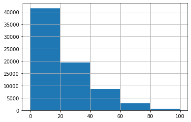

```python
df_imputed.ChildPoverty.hist(bins=5)
```

The graph above shows the unbalanced distribution of classes before any processing. This dataset is extremely unbalanced, with the 1st class completely overwhelming the other classes. This would skew the accuracy results of our models as it would best predict test data belonging to the first class and perform poorly with any other test data belonging to any other class.

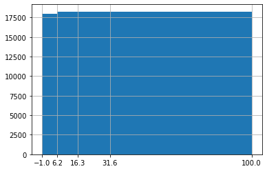

```python
# sort child poverty values
df_imputed.sort_values(by =['ChildPoverty'], inplace = True)
index = df_imputed.columns.get_loc("ChildPoverty")

plt.figure()

# create bins based on quartiles
bins_ = [-1, df_imputed.iloc[18178, index],  df_imputed.iloc[36350, index], df_imputed.iloc[54545, index], df_imputed.iloc[72717, index]]

df_imputed.ChildPoverty.hist(bins = bins_)
plt.xticks(bins_)
plt.show()
```

```python
ChildPoverty = df_imputed.ChildPoverty
ChildPoverty_incode = pd.cut(ChildPoverty,bins_,labels=False)
df_imputed['ChildPoverty_'] = ChildPoverty_incode
```

We will one-hot encode the `ChildPoverty` feature. This allows the model to be able to understand and extract information.

```python
enc = OneHotEncoder()
t = enc.fit_transform(df_imputed[['ChildPoverty_']]).toarray()
print(t)
```

```
[[1. 0. 0. 0.]
 [1. 0. 0. 0.]
 [1. 0. 0. 0.]
 ...
 [0. 0. 0. 1.]
 [0. 0. 0. 1.]
 [0. 0. 0. 1.]]
```

### Splitting Dataset

Now we will split the dataset into 80% for training and 20% for testing.

```python
from sklearn.model_selection import ShuffleSplit

# we want to predict the X and y data as follows:
if 'ChildPoverty_' in df_imputed:
    y = df_imputed.pop('ChildPoverty_') # get the labels we want
    X = df_imputed # use everything else to predict!
```

```python
from sklearn.model_selection import train_test_split
X_train, X_test, y_train, y_test = train_test_split(X,y,test_size = 0.2)
```

```python
print("Train Size: ", X_train.shape[0], "rows")
print("Test size: ", X_test.shape[0], "rows")
```

```
Train Size:  58174 rows
Test size:  14544 rows
```

```python
print("The shape of the data matrix: " + str(X.shape))
print("The shape of the target variable: " + str(y.shape))
```

```
The shape of the data matrix: (72718, 37)
The shape of the target variable: (72718,)
```

```python
print("The training matrix and target shapes: " + str(X_train.shape)+ ' & ' + str(y_train.shape))
print("The testing matrix and target shapes: " + str(X_test.shape)+ ' & ' + str(y_test.shape))
```

```
The training matrix and target shapes: (58174, 37) & (58174,)
The testing matrix and target shapes: (14544, 37) & (14544,)
```

```python
X_train
```

|  | TractId | State | County | TotalPop | Men | Women | Hispanic | White | Black | Native | ... | Walk | OtherTransp | WorkAtHome | MeanCommute | Employed | PrivateWork | PublicWork | SelfEmployed | FamilyWork | Unemployment |
| --- | --- | --- | --- | --- | --- | --- | --- | --- | --- | --- | --- | --- | --- | --- | --- | --- | --- | --- | --- | --- | --- |
| 14722 | 12017450101 | 9 | 9 | 6399 | 3091 | 3308 | 5.5 | 86.3 | 3.3 | 0.0 | ... | 0.0 | 2.7 | 2.5 | 20.9 | 1973 | 78.5 | 16.3 | 5.3 | 0.0 | 8.8 |
| 68024 | 51059430600 | 47 | 47 | 6946 | 3556 | 3390 | 38.2 | 24.8 | 5.4 | 0.2 | ... | 3.9 | 4.3 | 1.1 | 33.4 | 4014 | 83.3 | 12.1 | 4.3 | 0.3 | 4.2 |
| 4101 | 6013345108 | 4 | 4 | 7360 | 3667 | 3693 | 5.9 | 49.1 | 3.4 | 0.4 | ... | 0.5 | 0.7 | 8.8 | 32.2 | 3947 | 84.0 | 10.3 | 5.7 | 0.0 | 3.7 |
| 33675 | 26093712101 | 22 | 22 | 3040 | 1449 | 1591 | 1.4 | 95.7 | 0.5 | 0.0 | ... | 1.5 | 0.5 | 5.3 | 29.2 | 1528 | 82.0 | 10.3 | 5.2 | 2.4 | 1.0 |
| 57092 | 42073010100 | 38 | 38 | 3670 | 1806 | 1864 | 0.3 | 97.0 | 0.3 | 0.6 | ... | 2.0 | 1.2 | 3.4 | 26.6 | 1758 | 85.0 | 11.2 | 3.8 | 0.0 | 3.6 |
| ... | ... | ... | ... | ... | ... | ... | ... | ... | ... | ... | ... | ... | ... | ... | ... | ... | ... | ... | ... | ... | ... |
| 344 | 1061050600 | 0 | 0 | 3983 | 1953 | 2030 | 2.1 | 94.8 | 1.9 | 0.0 | ... | 0.7 | 1.5 | 5.2 | 29.1 | 1719 | 78.6 | 12.3 | 9.1 | 0.0 | 5.5 |
| 17589 | 12103025401 | 9 | 9 | 4705 | 2324 | 2381 | 6.0 | 84.3 | 3.5 | 0.3 | ... | 0.3 | 0.9 | 6.0 | 26.0 | 2409 | 78.1 | 14.6 | 7.3 | 0.0 | 5.3 |
| 59779 | 45083022003 | 41 | 41 | 4201 | 1893 | 2308 | 5.4 | 67.4 | 24.6 | 0.0 | ... | 0.0 | 0.0 | 3.0 | 24.6 | 1717 | 83.8 | 10.4 | 5.8 | 0.0 | 6.2 |
| 64834 | 48215023513 | 44 | 44 | 9183 | 4240 | 4943 | 93.8 | 4.9 | 0.5 | 0.0 | ... | 2.0 | 10.1 | 1.2 | 37.1 | 3190 | 78.6 | 13.5 | 7.9 | 0.0 | 5.1 |
| 22314 | 17031831500 | 13 | 13 | 3540 | 1667 | 1873 | 64.8 | 25.3 | 4.0 | 0.0 | ... | 0.9 | 2.8 | 2.6 | 41.7 | 1867 | 88.9 | 9.2 | 1.9 | 0.0 | 7.3 |

58174 rows × 37 columns

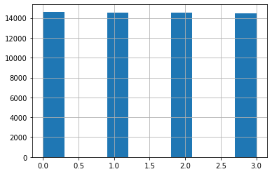

```python
y_train.hist()
```

The above histogram shows the distribution of the `ChildPoverty` values among the different classes. We don't need to worry about an unbalanced dataset or the model having bias towards one class anymore.

## Pre-Processing and Initial Modeling

We will be building 3 different perceptron models. Each perceptron model with have:

- Vectorized Gradient Calculation
- Mini-batching
- Loss Cross Entropy
- Proper Glorot Initialization

The three different perceptron models are:

For comparing the performance of all three models, we will use the following parameters. We will compare the performance of all three models towards the end of this section.

```python
# training on our data
vals = {
    'n_hidden':50,
    'C':1e-2,
    'epochs':400,
    'eta':0.001,
    'alpha':0.1,
    'decrease_const':0.1,
    'decrease_iter':20,
    'minibatches':int(len(X_train))/256,
    'shuffle':True,
    'random_state':1
}
```

### Normal Perceptron Model

#### Base Model

```python
#Example adapted from https://github.com/rasbt/python-machine-learning-book/blob/master/code/ch12/ch12.ipynb
#Original Author: Sebastian Raschka

from scipy.special import expit
import sys

class TwoLayerPerceptronBase(object):
    def __init__(self, n_hidden=30, C=0.0, epochs=500, eta=0.001, random_state=None):
        np.random.seed(random_state)
        self.n_hidden = n_hidden    # first hidden layer nodes

        self.l2_C = C
        self.epochs = epochs
        self.eta = eta

    @staticmethod
    def _encode_labels(y):
        # One-Hot encode labels
        onehot = pd.get_dummies(y).values.T
        return onehot

    def _initialize_weights(self):
        # initialize weights with small random numbers
        W1_num_elems = (self.n_features_)*self.n_hidden
        W1 = np.random.uniform(-1.0, 1.0, size=W1_num_elems)
        W1 = W1.reshape(self.n_hidden, self.n_features_)
        b1 = np.zeros((self.n_hidden, 1))

        W2_num_elems = (self.n_hidden)*self.n_output_
        W2 = np.random.uniform(-1.0, 1.0, size=W2_num_elems)
        W2 = W2.reshape(self.n_output_, self.n_hidden)
        b2 = np.zeros((self.n_output_, 1))

        return W1, W2, b1, b2,

    @staticmethod
    def _sigmoid(z):
        # 1.0 / (1.0 + np.exp(-z))
        return expit(z)


    @staticmethod
    def _L2_reg(lambda_, W1, W2):
        # compute L2-regularization cost using W1, W2, W3

        # only compute for non-bias terms
        return (lambda_) * np.sqrt(np.mean(W1 ** 2) + np.mean(W2 ** 2))

    def _cost(self,A3,Y_enc,W1,W2):
        cost = np.mean((Y_enc-A3)**2)
        L2_term = self._L2_reg(self.l2_C, W1, W2)

        return cost + L2_term
```

```python
# adding feedforward and fit and predict functions
class TwoLayerPerceptron(TwoLayerPerceptronBase):
    def _feedforward(self, X, W1, W2, b1, b2):
        """
        X : Input layer with original features.
        W1: Weight matrix for input layer -> hidden layer.
        W2: Weight matrix for hidden layer -> output layer.
        ----------
        a1-a3 : activations into layer (or output layer)
        z1-z2 : layer inputs
        """

        # feedforward into first hidden layer
        A1 = X.T
        Z1 = W1 @ A1 + b1
        A2 = self._sigmoid(Z1)

        # feedforward into second hidden layer
        Z2 = W2 @ A2 + b2
        A3 = self._sigmoid(Z2)

        return A1, Z1, A2, Z2, A3

    def _get_gradient(self, A1, A2, A3, Z1, Z2, Y_enc, W1, W2):
        pass


    def predict(self, X):
        _, _, _, _, A3 = self._feedforward(X, self.W1, self.W2, self.b1, self.b2)

        y_pred = np.argmax(A3, axis=0)
        return y_pred


    def fit(self, X, y, print_progress=False):
        # learn weights from training data

        X_data, y_data = X.copy(), y.copy()
        Y_enc = self._encode_labels(y)

        # init weights and setup matrices
        self.n_features_ = X_data.shape[1]
        self.n_output_ = Y_enc.shape[0]
        self.W1, self.W2, self.b1, self.b2, = self._initialize_weights()

        self.cost_ = []

        for i in range(self.epochs):
            if print_progress>0 and (i+1)%print_progress==0:
                sys.stderr.write('\rEpoch: %d/%d' % (i+1, self.epochs))
                sys.stderr.flush()

            # feedforward all instances
            A1, Z1, A2, Z2, A3 = self._feedforward(X_data,self.W1,self.W2,self.b1,self.b2)

            cost = self._cost(A3,Y_enc,self.W1,self.W2)
            self.cost_.append(cost)

            # compute gradient via backpropagation
            gradW1, gradW2, gradb1, gradb2 = self._get_gradient(A1=A1, A2=A2, A3=A3, Z1=Z1, Z2=Z2, Y_enc=Y_enc,
            W1=self.W1, W2=self.W2)

            self.W1 -= self.eta * gradW1
            self.W2 -= self.eta * gradW2

            self.b1 -= self.eta * gradb1
            self.b2 -= self.eta * gradb2

        return self
```

#### Vectorized Gradient Computation

The gradient calculations can be optimized using vectors instead of for-loops. We only need to modify the _get_gradient function.

```python
class TwoLayerPerceptronVectorized(TwoLayerPerceptron):
    def _get_gradient(self, A1, A2, A3, Z1, Z2, Y_enc, W1, W2):
        # vectorized backpropagation
        V2 = -2*(Y_enc-A3)*A3*(1-A3)
        V1 = A2*(1-A2)*(W2.T @ V2)

        gradW2 = V2 @ A2.T
        gradW1 = V1 @ A1.T

        gradb2 = np.sum(V2, axis=1).reshape((-1,1))
        gradb1 = np.sum(V1, axis=1).reshape((-1,1))

        # regularize weights that are not bias terms
        gradW1 += W1 * self.l2_C
        gradW2 += W2 * self.l2_C

        return gradW1, gradW2, gradb1, gradb2
```

#### Mini-batching

Instead of considering the entire dataset, this model trains itself using sub-datasets, increasing the model's speed.

```python
# adding mini-batching to Two Layer Perceptron class
class TLPMiniBatch(TwoLayerPerceptronVectorized):
    def __init__(self, alpha=0.0, decrease_const=0.1, decrease_iter = 10, shuffle=True, minibatches=1, **kwds):
        # need to add to the original initializer
        self.alpha = alpha
        self.decrease_const = decrease_const
        self.decrease_iter = decrease_iter
        self.shuffle = shuffle
        self.minibatches = minibatches

        # but keep other keywords
        super().__init__(**kwds)


    def fit(self, X, y, print_progress=False, XY_test=None):
        # learn weights from training data with mini-batch
        X_data, y_data = X.copy(), y.copy()
        Y_enc = self._encode_labels(y)

        # init weights and setup matrices
        self.n_features_ = X_data.shape[1]
        self.n_output_ = Y_enc.shape[0]
        self.W1, self.W2, self.b1, self.b2 = self._initialize_weights()

        # start momentum at zero for previous updates
        rho_W1_prev = np.zeros(self.W1.shape) # for momentum
        rho_W2_prev = np.zeros(self.W2.shape) # for momentum

        self.cost_ = []
        self.score_ = []

        # get starting acc
        self.score_.append(accuracy_score(y_data,self.predict(X_data)))

        # keep track of validation, if given
        if XY_test is not None:
            X_test = XY_test[0].copy()
            y_test = XY_test[1].copy()
            self.val_score_ = []
            self.val_score_.append(accuracy_score(y_test,self.predict(X_test)))
            self.val_cost_ = []

        for i in range(self.epochs):
            eta = self.eta

            if print_progress>0 and (i+1)%print_progress==0:
                sys.stderr.write('\rEpoch: %d/%d' % (i+1, self.epochs))
                sys.stderr.flush()

            if self.shuffle:
                idx_shuffle = np.random.permutation(y_data.shape[0])
                X_data, Y_enc, y_data = X_data[idx_shuffle], Y_enc[:, idx_shuffle], y_data[idx_shuffle]

            mini = np.array_split(range(y_data.shape[0]), self.minibatches)
            mini_cost = []
            for idx in mini:

                # feedforward
                A1, Z1, A2, Z2, A3 = self._feedforward(X_data[idx],
                                                       self.W1,
                                                       self.W2,
                                                       self.b1,
                                                       self.b2
                                                      )

                cost = self._cost(A3,Y_enc[:, idx],self.W1,self.W2)
                mini_cost.append(cost) # this appends cost of mini-batch only

                # compute gradient via backpropagation
                gradW1, gradW2, gradb1, gradb2 = self._get_gradient(A1=A1, A2=A2, A3=A3, Z1=Z1, Z2=Z2,
                                                  Y_enc=Y_enc[:, idx],
                                                  W1=self.W1,W2=self.W2)

                # momentum calculations
                rho_W1, rho_W2 = eta * gradW1, eta * gradW2

                self.W1 -= (rho_W1 + (self.alpha * rho_W1_prev)) # update with momentum
                self.W2 -= (rho_W2 + (self.alpha * rho_W2_prev)) # update with momentum

                self.b1 -= eta * gradb1
                self.b2 -= eta * gradb2

                rho_W1_prev, rho_W2_prev = rho_W1, rho_W2


            self.cost_.append(np.mean(mini_cost))
            self.score_.append(accuracy_score(y_data,self.predict(X_data)))
            if XY_test is not None:
                yhat = self.predict(X_test)
                self.val_score_.append(accuracy_score(y_test,yhat))

        return self
```

#### Cross Entropy Loss

Using Cross Entropy Loss allows us to quantify how our model is performing. We want our Cross Entropy Loss to be as close to 0 as possible.

```python
# add cross entropy to TLPMiniBatch class
class TLPMiniBatchCrossEntropy(TLPMiniBatch):
    def _cost(self,A3,Y_enc,W1,W2):
        cost = -np.mean(np.nan_to_num((Y_enc*np.log(A3)+(1-Y_enc)*np.log(1-A3))))
        L2_term = self._L2_reg(self.l2_C, W1, W2)

        return cost + L2_term

    def _get_gradient(self, A1, A2, A3, Z1, Z2, Y_enc, W1, W2):
        # compute gradient step using backpropagation

        # vectorized backpropagation
        V2 = (A3-Y_enc)
        V1 = A2*(1-A2)*(W2.T @ V2)

        gradW2 = V2 @ A2.T
        gradW1 = V1 @ A1.T

        gradb2 = np.sum(V2, axis=1).reshape((-1,1))
        gradb1 = np.sum(V1, axis=1).reshape((-1,1))

        # regularize weights that are not bias terms
        gradW1 += W1 * self.l2_C
        gradW2 += W2 * self.l2_C

        return gradW1, gradW2, gradb1, gradb2
```

#### Glorot Initialization

Glorot Initialization allows our model to initialize the weights using a uniform distribution.

```python
# derive class with Glorot Initialization
class TLPBetterInitial(TLPMiniBatchCrossEntropy):
    def _initialize_weights(self):
        # initialize weights Glorot and He normalization
        init_bound = 4*np.sqrt(6. / (self.n_hidden + self.n_features_))
        W1 = np.random.uniform(-init_bound, init_bound,(self.n_hidden, self.n_features_))

        # reduce the final layer magnitude in order to balance the size of the gradients
        init_bound = 4*np.sqrt(6 / (self.n_output_ + self.n_hidden))
        W2 = np.random.uniform(-init_bound, init_bound,(self.n_output_, self.n_hidden))

        b1 = np.zeros((self.n_hidden, 1))
        b2 = np.zeros((self.n_output_, 1))

        return W1, W2, b1, b2
```

#### Normal Model

```python
# normal model
nn1 = TLPBetterInitial(**vals)
nn1.fit(X_train.to_numpy(), y_train.to_numpy(), print_progress=1)

yhat = nn1.predict(X_test.to_numpy())
acc1 = accuracy_score(y_test.to_numpy(),yhat)
print('Accuracy:',acc1)
```

```
Epoch: 400/400
```

```
Accuracy: 0.2484185918591859
```

### Normalized-Continuous Data Model

Our normal perceptron model is complete with its optimization techniques. We will build another model and use the dataset where we normalize the continuous features.

```python
# import libraries
from sklearn.preprocessing import StandardScaler
from sklearn.model_selection import train_test_split
from sklearn.model_selection import ShuffleSplit
```

```python
# create copy of data
df_new = copy.deepcopy(df_imputed)
```

```python
# drop columns
df_new = df_new.drop(columns =['State', 'County', 'TractId'] ,axis = 1)
```

```python
# we want to predict the X and y data as follows:
if 'ChildPoverty_' in df_new:
    y = df_new.pop('ChildPoverty_') # get the labels we want
    X = df_new # use everything else to predict!

# split data into train and test
X_train, X_test, y_train, y_test = train_test_split(X,y,test_size = 0.2)
```

```python
# Normalized-Continuous Data Model
# normalize continuous numeric features data using standardization
scaler = StandardScaler()
X_train = scaler.fit_transform(X_train)
X_test = scaler.fit_transform(X_test)

nn2 = TLPBetterInitial(**vals)
nn2.fit(X_train, y_train.to_numpy(), print_progress=1)

yhat = nn2.predict(X_test)
acc2 = accuracy_score(y_test.to_numpy(),yhat)
print('Accuracy:',acc2)
```

```
Epoch: 400/400
```

```
Accuracy: 0.9916116611661167
```

### Normalized-Continuous Data & One-Hot Encoding Model

```python
# One-Hot Encoding
S1 = pd.get_dummies(df_imputed['State'])
S2 = pd.get_dummies(df_imputed['County'])
```

```python
# concatenate the dummy variables
X1 = pd.concat([S1, S2],axis =1)
X = pd.concat([X1,df_new], axis= 1)
```

```python
# reconstructing data matrix
X_train, X_test, y_train, y_test = train_test_split(X, y, test_size=0.2, random_state=0, stratify = y)

nn3 = TLPBetterInitial(**vals)
nn3.fit(X_train.to_numpy(), y_train.to_numpy(), print_progress=1)

yhat = nn3.predict(X_test.to_numpy())
acc3 = accuracy_score(y_test.to_numpy(),yhat)
print('Accuracy:',acc3)
```

```
Epoch: 400/400
```

```
Accuracy: 0.2511001100110011
```

### Performance Comparison

Now that we've developed our three different perceptron models, we will compare their accuracy and performance side-by-side.

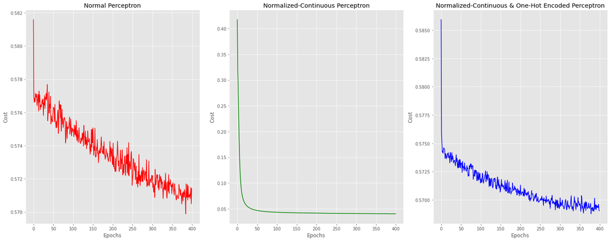

```
Accuracy of Normal Perceptron Model :  0.2484185918591859
Accuracy of Normalized-Continuous Perceptron Model:  0.9916116611661167
Accuracy of Normalized-Continuous & One-Hot Encoded Perceptron Model:  0.2511001100110011
```

```python
# plot cost vs number of epochs in subplots
plt.style.use('ggplot')
fig = plt.figure(figsize=(20,8))

# normal perceptron subplot
plt.subplot(1,3,1)
ax1 = plt.plot(range(len(nn1.cost_)), nn1.cost_, label='Normal', color='red')
plt.subplot(1,3,1).set_title('Normal Perceptron')
plt.subplot(1,3,1).set_xlabel('Epochs')
plt.subplot(1,3,1).set_ylabel('Cost')

# normalized continuous data subplot
plt.subplot(1,3,2)
ax2 = plt.plot(range(len(nn2.cost_)), nn2.cost_, label='Normalized-Continuous', color='green')
plt.subplot(1,3,2).set_title('Normalized-Continuous Perceptron')
plt.subplot(1,3,2).set_xlabel('Epochs')
plt.subplot(1,3,2).set_ylabel('Cost')

# normalized continuous data and one-hot-encoded data subplot
plt.subplot(1,3,3)
ax3 = plt.plot(range(len(nn3.cost_)), nn3.cost_, label='Normalized-Continuous & One-Hot Encoded', color='blue')
plt.subplot(1,3,3).set_title('Normalized-Continuous & One-Hot Encoded Perceptron')
plt.subplot(1,3,3).set_xlabel('Epochs')
plt.subplot(1,3,3).set_ylabel('Cost')

plt.tight_layout()
plt.show()

# print accuracy scores
print('Accuracy of Normal Perceptron Model : ',acc1)
print('Accuracy of Normalized-Continuous Perceptron Model: ',acc2)
print('Accuracy of Normalized-Continuous & One-Hot Encoded Perceptron Model: ',acc3)
```

Model 2 (green) outperforms the other models significantly. The model's cost is diminished from **0.40** to below **0.05** near epoch #25, and remains constant until the end.

Model 1 (red) and 3 (blue) share a similar graph, with both graphs beginning their gradual descent near epoch #0. However, the amplitude of the graph for Model 3 are much smaller and controlled in comparison to Model 1. Additionally, Model 3's gradual descent starts near **0.5750**, in comparison to Model 1's **0.5777**.

## Modeling

### Third Layer Perceptron

We've developed our two layer perceptron with the different optimization techniques, but now we will be adding a third hidden layer.

```python
from scipy.special import expit
import sys

class ThreeLayerPerceptronBase(object):
    def __init__(self, n_hidden=30, n_hidden2 = 15, C=0.0, epochs=500, eta=0.001, random_state=None):
        np.random.seed(random_state)
        self.n_hidden = n_hidden    # first hidden layer nodes
        self.n_hidden2 = n_hidden2  # second hidden layer nodes

        self.l2_C = C
        self.epochs = epochs
        self.eta = eta

    @staticmethod
    def _encode_labels(y):
        # One-Hot encode labels
        onehot = pd.get_dummies(y).values.T
        return onehot

    def _initialize_weights(self):
        # initialize weights with small random numbers
        W1_num_elems = (self.n_features_)*self.n_hidden
        W1 = np.random.uniform(-1.0, 1.0, size=W1_num_elems)
        W1 = W1.reshape(self.n_hidden, self.n_features_)
        b1 = np.zeros((self.n_hidden, 1))

        W2_num_elems = (self.n_hidden)*self.n_hidden2
        W2 = np.random.uniform(-1.0, 1.0, size=W2_num_elems)
        W2 = W2.reshape(self.n_hidden2, self.n_hidden)
        b2 = np.zeros((self.n_hidden2, 1))

        W3_num_elems = (self.n_hidden2)*self.n_output_
        W3 = np.random.uniform(-1.0, 1.0, size=W3_num_elems)
        W3 = W3.reshape(self.n_output_, self.n_hidden2)
        b3 = np.zeros((self.n_output_, 1))

        return W1, W2, W3, b1, b2, b3

    @staticmethod
    def _sigmoid(z):
        # 1.0 / (1.0 + np.exp(-z))
        return expit(z)

    @staticmethod
    def _L2_reg(lambda_, W1, W2, W3):
        # compute L2-regularization cost using W1, W2, W3

        # only compute for non-bias terms
        return (lambda_) * np.sqrt(np.mean(W1 ** 2) + np.mean(W2 ** 2) + np.mean(W3 ** 2))

    def _cost(self,A4,Y_enc,W1,W2,W3):
        cost = np.mean((Y_enc-A4)**2)
        L2_term = self._L2_reg(self.l2_C, W1, W2, W3)

        return cost + L2_term
```

```python
# adding feedforward and fit and predict functions
class ThreeLayerPerceptron(ThreeLayerPerceptronBase):
    def _feedforward(self, X, W1, W2, W3, b1, b2, b3):
        """
        X : Input layer with original features.
        W1: Weight matrix for input layer -> hidden layer1.
        W2: Weight matrix for hidden layer1 -> hidden layer 2.
        W3: Weight matrix for hidden layer2 -> output layer.
        ----------
        a1-a4 : activations into layer (or output layer)
        z1-z3 : layer inputs
        """

        # feedforward into first hidden layer
        A1 = X.T
        Z1 = W1 @ A1 + b1
        A2 = self._sigmoid(Z1)

        # feedforward into second hidden layer
        Z2 = W2 @ A2 + b2
        A3 = self._sigmoid(Z2)

        # feedforward into third hidden layer/output layer
        Z3 = W3 @ A3 + b3
        A4 = self._sigmoid(Z3)

        return A1, Z1, A2, Z2, A3, Z3, A4

    def _get_gradient(self, A1, A2, A3, A4, Z1, Z2, Z3, Y_enc, W1, W2, W3):
        pass


    def predict(self, X):
        _, _, _, _, _, _, A4 = self._feedforward(X, self.W1, self.W2, self.W3, self.b1, self.b2, self.b3)

        y_pred = np.argmax(A4, axis=0)
        return y_pred


    def fit(self, X, y, print_progress=False):
        # learn weights from training data

        X_data, y_data = X.copy(), y.copy()
        Y_enc = self._encode_labels(y)

        # init weights and setup matrices
        self.n_features_ = X_data.shape[1]
        self.n_output_ = Y_enc.shape[0]
        self.W1, self.W2, self.W3, self.b1, self.b2, self.b3 = self._initialize_weights()

        self.cost_ = []

        for i in range(self.epochs):
            if print_progress>0 and (i+1)%print_progress==0:
                sys.stderr.write('\rEpoch: %d/%d' % (i+1, self.epochs))
                sys.stderr.flush()

            # feedforward all instances
            A1, Z1, A2, Z2, A3, Z3, A4 = self._feedforward(X_data,self.W1,self.W2,self.W3,self.b1,self.b2,self.b3)

            cost = self._cost(A4,Y_enc,self.W1,self.W2,self.W3)
            self.cost_.append(cost)

            # compute gradient via backpropagation
            gradW1, gradW2, gradW3, gradb1, gradb2, gradb3 = self._get_gradient(A1=A1, A2=A2, A3=A3, A4=A4, Z1=Z1, Z2=Z2, Z3=Z3, Y_enc=Y_enc,
            W1=self.W1, W2=self.W2, W3=self.W3)

            self.W1 -= self.eta * gradW1
            self.W2 -= self.eta * gradW2
            self.W3 -= self.eta * gradW3

            self.b1 -= self.eta * gradb1
            self.b2 -= self.eta * gradb2
            self.b3 -= self.eta * gradb3

        return self
```

#### Optimization Techniques

```python
class ThreeLayerPerceptronVectorized(ThreeLayerPerceptron):
    def _get_gradient(self, A1, A2, A3, A4, Z1, Z2, Z3, Y_enc, W1, W2, W3):
        # vectorized backpropagation
        V3 = -2*(Y_enc-A4)*A4*(1-A4)
        V2 = A3*(1-A3)*(W3.T @ V3)
        V1 = A2*(1-A2)*(W2.T @ V2)

        gradW3 = V3 @ A3.T
        gradW2 = V2 @ A2.T
        gradW1 = V1 @ A1.T

        gradb3 = np.sum(V3, axis=1).reshape((-1,1))
        gradb2 = np.sum(V2, axis=1).reshape((-1,1))
        gradb1 = np.sum(V1, axis=1).reshape((-1,1))

        # regularize weights that are not bias terms
        gradW1 += W1 * self.l2_C
        gradW2 += W2 * self.l2_C
        gradW3 += W3 * self.l2_C

        return gradW1, gradW2, gradW3, gradb1, gradb2, gradb3
```

```python
# adding mini-batching to Two Layer Perceptron class
class T3LPMiniBatch(ThreeLayerPerceptronVectorized):
    def __init__(self, alpha=0.0, decrease_const=0.1, decrease_iter = 10, shuffle=True, minibatches=1, **kwds):
        # need to add to the original initializer
        self.alpha = alpha
        self.decrease_const = decrease_const
        self.decrease_iter = decrease_iter
        self.shuffle = shuffle
        self.minibatches = minibatches

        # but keep other keywords
        super().__init__(**kwds)


    def fit(self, X, y, print_progress=False, XY_test=None):
        # learn weights from training data with mini-batch
        X_data, y_data = X.copy(), y.copy()
        Y_enc = self._encode_labels(y)

        # init weights and setup matrices
        self.n_features_ = X_data.shape[1]
        self.n_output_ = Y_enc.shape[0]
        self.W1, self.W2, self.W3, self.b1, self.b2, self.b3 = self._initialize_weights()

        # start momentum at zero for previous updates
        rho_W1_prev = np.zeros(self.W1.shape) # for momentum
        rho_W2_prev = np.zeros(self.W2.shape) # for momentum
        rho_W3_prev = np.zeros(self.W3.shape) # for momentum

        # create arrays for average magnitude of weights
        self.grad_w1_ = np.zeros(self.epochs)
        self.grad_w2_ = np.zeros(self.epochs)
        self.grad_w3_ = np.zeros(self.epochs)

        self.cost_ = []
        self.score_ = []

        # get starting acc
        self.score_.append(accuracy_score(y_data,self.predict(X_data)))

        # keep track of validation, if given
        if XY_test is not None:
            X_test = XY_test[0].copy()
            y_test = XY_test[1].copy()
            self.val_score_ = []
            self.val_score_.append(accuracy_score(y_test,self.predict(X_test)))
            self.val_cost_ = []

        for i in range(self.epochs):
            eta = self.eta

            if print_progress>0 and (i+1)%print_progress==0:
                sys.stderr.write('\rEpoch: %d/%d' % (i+1, self.epochs))
                sys.stderr.flush()

            if self.shuffle:
                idx_shuffle = np.random.permutation(y_data.shape[0])
                X_data, Y_enc, y_data = X_data[idx_shuffle], Y_enc[:, idx_shuffle], y_data[idx_shuffle]

            mini = np.array_split(range(y_data.shape[0]), self.minibatches)
            mini_cost = []

            self.grad_w1_batch = []
            self.grad_w2_batch = []
            self.grad_w3_batch = []

            for idx in mini:

                # feedforward
                A1, Z1, A2, Z2, A3, Z3, A4 = self._feedforward(X_data[idx],
                                                       self.W1,
                                                       self.W2,
                                                       self.W3,
                                                       self.b1,
                                                       self.b2,
                                                       self.b3
                                                      )

                cost = self._cost(A4,Y_enc[:, idx],self.W1,self.W2,self.W3)
                mini_cost.append(cost) # this appends cost of mini-batch only

                # compute gradient via backpropagation
                gradW1, gradW2, gradW3, gradb1, gradb2, gradb3 = self._get_gradient(A1=A1, A2=A2, A3=A3, A4=A4, Z1=Z1, Z2=Z2, Z3=Z3,
                                                  Y_enc=Y_enc[:, idx],
                                                  W1=self.W1,W2=self.W2,W3=self.W3)

                # append average magnitude of weights to array
                self.grad_w1_batch.append(np.mean(np.abs(gradW1)))
                self.grad_w2_batch.append(np.mean(np.abs(gradW2)))
                self.grad_w3_batch.append(np.mean(np.abs(gradW3)))

                # momentum calculations
                rho_W1, rho_W2, rho_W3 = eta * gradW1, eta * gradW2, eta * gradW3

                self.W1 -= (rho_W1 + (self.alpha * rho_W1_prev)) # update with momentum
                self.W2 -= (rho_W2 + (self.alpha * rho_W2_prev)) # update with momentum
                self.W3 -= (rho_W3 + (self.alpha * rho_W3_prev)) # update with momentum

                self.b1 -= eta * gradb1
                self.b2 -= eta * gradb2
                self.b3 -= eta * gradb3

                rho_W1_prev, rho_W2_prev, rho_W3_prev = rho_W1, rho_W2, rho_W3

            # turn lists into arrays
            self.grad_w1_batch = np.array(self.grad_w1_batch)
            self.grad_w2_batch = np.array(self.grad_w2_batch)
            self.grad_w3_batch = np.array(self.grad_w3_batch)

            # average the average magnitude of weights
            self.grad_w1_[i] = np.mean(self.grad_w1_batch)
            self.grad_w2_[i] = np.mean(self.grad_w2_batch)
            self.grad_w3_[i] = np.mean(self.grad_w3_batch)

            self.cost_.append(np.mean(mini_cost))
            self.score_.append(accuracy_score(y_data,self.predict(X_data)))
            if XY_test is not None:
                yhat = self.predict(X_test)
                self.val_score_.append(accuracy_score(y_test,yhat))

        return self
```

```python
# add cross entropy to TLPMiniBatch class
class T3LPMiniBatchCrossEntropy(T3LPMiniBatch):
    def _cost(self,A4,Y_enc,W1,W2,W3):
        cost = -np.mean(np.nan_to_num((Y_enc*np.log(A4)+(1-Y_enc)*np.log(1-A4))))
        L2_term = self._L2_reg(self.l2_C, W1, W2, W3)

        return cost + L2_term

    def _get_gradient(self, A1, A2, A3, A4, Z1, Z2, Z3, Y_enc, W1, W2, W3):
        # compute gradient step using backpropagation

        # vectorized backpropagation
        V3 = (A4-Y_enc) # <- this is only line that changed
        V2 = A3*(1-A3)*(W3.T @ V3)
        V1 = A2*(1-A2)*(W2.T @ V2)

        gradW3 = V3 @ A3.T
        gradW2 = V2 @ A2.T
        gradW1 = V1 @ A1.T

        gradb3 = np.sum(V3, axis=1).reshape((-1,1))
        gradb2 = np.sum(V2, axis=1).reshape((-1,1))
        gradb1 = np.sum(V1, axis=1).reshape((-1,1))

        # regularize weights that are not bias terms
        gradW1 += W1 * self.l2_C
        gradW2 += W2 * self.l2_C
        gradW3 += W3 * self.l2_C

        return gradW1, gradW2, gradW3, gradb1, gradb2, gradb3
```

```python
# derive class with Glorot Initialization
class T3LPBetterInitial(T3LPMiniBatchCrossEntropy):
    def _initialize_weights(self):
        # initialize weights Glorot and He normalization
        init_bound = 4*np.sqrt(6. / (self.n_hidden + self.n_features_))
        W1 = np.random.uniform(-init_bound, init_bound,(self.n_hidden, self.n_features_))

        # reduce the final layer magnitude in order to balance the size of the gradients
        init_bound = 4*np.sqrt(6 / (self.n_hidden2 + self.n_hidden))
        W2 = np.random.uniform(-init_bound, init_bound,(self.n_hidden2, self.n_hidden))

        init_bound = 4*np.sqrt(6 / (self.n_output_ + self.n_hidden2))
        W3 = np.random.uniform(-init_bound, init_bound,(self.n_output_, self.n_hidden2))

        b1 = np.zeros((self.n_hidden, 1))
        b2 = np.zeros((self.n_hidden2, 1))
        b3 = np.zeros((self.n_output_, 1))

        return W1, W2, W3, b1, b2, b3
```

#### Testing Perceptron

We've implemented our third hidden layer in our perceptron model. We will test the model using the following params below:

```python
# training on our data
l3val = {
    'n_hidden':50,
    'n_hidden2':40,
    'C':1e-1,
    'epochs':400,
    'eta':0.001,
    'alpha':0.1,
    'decrease_const':0.1,
    'decrease_iter':20,
    'minibatches':int(len(X_train))/256,
    'shuffle':True,
    'random_state':1
}
```

```python
nn3L = T3LPBetterInitial(**l3val)
nn3L.fit(X_train.to_numpy(), y_train.to_numpy(), print_progress=1)

yhat = nn3L.predict(X_test.to_numpy())
acc3L = accuracy_score(y_test.to_numpy(),yhat)
print('Accuracy:',acc3L)
```

```
Epoch: 400/400
```

```
Accuracy: 0.2495874587458746
```

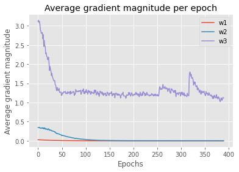

```python
plt.plot(abs(nn3L.grad_w1_[10:]), label='w1')
plt.plot(abs(nn3L.grad_w2_[10:]), label='w2')
plt.plot(abs(nn3L.grad_w3_[10:]), label='w3')

plt.legend()
plt.title('Average gradient magnitude per epoch')
plt.ylabel('Average gradient magnitude')
plt.xlabel('Epochs')
plt.show()
```

We observe from the three layer perceptron model that the average gradient magnitude is highest from W3. The average gradient magnitude for W2 is much smaller, and it is nearly 0 for W1. The greatest rate of change tends to occur near the last hidden layer, an observation that matches what the graph presents.

### Fourth Layer Perceptron

We will repeat the same process, only this time we will add a fourth layer to the perceptron model.

```python
from scipy.special import expit
import sys

class FourLayerPerceptronBase(object):
    def __init__(self, n_hidden=30, n_hidden2 = 15, n_hidden3 = 7, C=0.0, epochs=500, eta=0.001, random_state=None):
        np.random.seed(random_state)
        self.n_hidden = n_hidden    # first hidden layer nodes
        self.n_hidden2 = n_hidden2  # second hidden layer nodes
        self.n_hidden3 = n_hidden3  # third hidden layer nodes

        self.l2_C = C
        self.epochs = epochs
        self.eta = eta

    @staticmethod
    def _encode_labels(y):
        # One-Hot encode labels
        onehot = pd.get_dummies(y).values.T
        return onehot

    def _initialize_weights(self):
        # initialize weights with small random numbers
        W1_num_elems = (self.n_features_)*self.n_hidden
        W1 = np.random.uniform(-1.0, 1.0, size=W1_num_elems)
        W1 = W1.reshape(self.n_hidden, self.n_features_)
        b1 = np.zeros((self.n_hidden, 1))

        W2_num_elems = (self.n_hidden)*self.n_hidden2
        W2 = np.random.uniform(-1.0, 1.0, size=W2_num_elems)
        W2 = W2.reshape(self.n_hidden2, self.n_hidden)
        b2 = np.zeros((self.n_hidden2, 1))

        W3_num_elems = (self.n_hidden2)*self.n_hidden3
        W3 = np.random.uniform(-1.0, 1.0, size=W3_num_elems)
        W3 = W3.reshape(self.n_hidden3, self.n_hidden2)
        b3 = np.zeros((self.n_hidden3, 1))

        W4_num_elems = (self.n_hidden3)*self.n_output_
        W4 = np.random.uniform(-1.0, 1.0, size=W4_num_elems)
        W4 = W4.reshape(self.n_output_, self.n_hidden3)
        b4 = np.zeros((self.n_output_, 1))

        return W1, W2, W3, W4, b1, b2, b3, b4

    @staticmethod
    def _sigmoid(z):
        # 1.0 / (1.0 + np.exp(-z))
        return expit(z)

    @staticmethod
    def _L2_reg(lambda_, W1, W2, W3, W4):
        # compute L2-regularization cost using W1, W2, W3, W4

        # only compute for non-bias terms
        return (lambda_) * np.sqrt(np.mean(W1 ** 2) + np.mean(W2 ** 2) + np.mean(W3 ** 2) + np.mean(W4 ** 2))

    def _cost(self,A5,Y_enc,W1,W2,W3,W4):
        cost = np.mean((Y_enc-A5)**2)
        L2_term = self._L2_reg(self.l2_C, W1, W2, W3, W4)

        return cost + L2_term
```

```python
# adding feedforward and fit and predict functions
class FourLayerPerceptron(FourLayerPerceptronBase):
    def _feedforward(self, X, W1, W2, W3, W4, b1, b2, b3, b4):
        """
        X : Input layer with original features.
        W1: Weight matrix for input layer -> hidden layer1.
        W2: Weight matrix for hidden layer1 -> hidden layer2.
        W3: Weight matrix for hidden layer2 -> hidden layer3.
        W4: Weight matrix for hidden layer3 -> output layer.
        ----------
        a1-a5 : activations into layer (or output layer)
        z1-z4 : layer inputs
        """

        # feedforward into first hidden layer
        A1 = X.T
        Z1 = W1 @ A1 + b1
        A2 = self._sigmoid(Z1)

        # feedforward into second hidden layer
        Z2 = W2 @ A2 + b2
        A3 = self._sigmoid(Z2)

        # feedforward into third hidden layer
        Z3 = W3 @ A3 + b3
        A4 = self._sigmoid(Z3)

        # feedforward into fourth hidden layer
        Z4 = W4 @ A4 + b4
        A5 = self._sigmoid(Z4)

        return A1, Z1, A2, Z2, A3, Z3, A4, Z4, A5

    def _get_gradient(self, A1, A2, A3, A4, A5, Z1, Z2, Z3, Z4, Y_enc, W1, W2, W3, W4):
        pass


    def predict(self, X):
        _, _, _, _, _, _, _, _, A5 = self._feedforward(X, self.W1, self.W2, self.W3, self.W4, self.b1, self.b2, self.b3, self.b4)

        y_pred = np.argmax(A5, axis=0)
        return y_pred


    def fit(self, X, y, print_progress=False):
        # learn weights from training data
        X_data, y_data = X.copy(), y.copy()
        Y_enc = self._encode_labels(y)

        # init weights and setup matrices
        self.n_features_ = X_data.shape[1]
        self.n_output_ = Y_enc.shape[0]
        self.W1, self.W2, self.W3, self.W4, self.b1, self.b2, self.b3, self.b4 = self._initialize_weights()

        self.cost_ = []

        for i in range(self.epochs):
            if print_progress>0 and (i+1)%print_progress==0:
                sys.stderr.write('\rEpoch: %d/%d' % (i+1, self.epochs))
                sys.stderr.flush()

            # feedforward all instances
            A1, Z1, A2, Z2, A3, Z3, A4, Z4, A5 = self._feedforward(X_data,self.W1,self.W2,self.W3,self.W4,self.b1,self.b2,self.b3,self.b4)

            cost = self._cost(A5,Y_enc,self.W1,self.W2,self.W3,self.W4)
            self.cost_.append(cost)

            # compute gradient via backpropagation
            gradW1, gradW2, gradW3, gradW4, gradb1, gradb2, gradb3, gradb4 = self._get_gradient(A1=A1, A2=A2, A3=A3, A4=A4, A5=A5, Z1=Z1, Z2=Z2, Z3=Z3, Z4=Z4,Y_enc=Y_enc,
            W1=self.W1, W2=self.W2, W3=self.W3, W4=self.W4)

            self.W1 -= self.eta * gradW1
            self.W2 -= self.eta * gradW2
            self.W3 -= self.eta * gradW3
            self.W4 -= self.eta * gradW4

            self.b1 -= self.eta * gradb1
            self.b2 -= self.eta * gradb2
            self.b3 -= self.eta * gradb3
            self.b4 -= self.eta * gradb4

        return self
```

#### Optimization Techniques

```python
class FourLayerPerceptronVectorized(FourLayerPerceptron):
    def _get_gradient(self, A1, A2, A3, A4, A5, Z1, Z2, Z3, Z4, Y_enc, W1, W2, W3, W4):
        # vectorized backpropagation
        V4 = -2*(Y_enc-A5)*A5*(1-A5)
        V3 = A4*(1-A4)*(W4.T @ V4)
        V2 = A3*(1-A3)*(W3.T @ V3)
        V1 = A2*(1-A2)*(W2.T @ V2)

        gradW4 = V4 @ A4.T
        gradW3 = V3 @ A3.T
        gradW2 = V2 @ A2.T
        gradW1 = V1 @ A1.T

        gradb4 = np.sum(V4, axis=1).reshape((-1,1))
        gradb3 = np.sum(V3, axis=1).reshape((-1,1))
        gradb2 = np.sum(V2, axis=1).reshape((-1,1))
        gradb1 = np.sum(V1, axis=1).reshape((-1,1))

        # regularize weights that are not bias terms
        gradW1 += W1 * self.l2_C
        gradW2 += W2 * self.l2_C
        gradW3 += W3 * self.l2_C
        gradW4 += W4 * self.l2_C

        return gradW1, gradW2, gradW3, gradW4, gradb1, gradb2, gradb3, gradb4
```

```python
# adding mini-batching to Two Layer Perceptron class
class FourLPMiniBatch(FourLayerPerceptronVectorized):
    def __init__(self, alpha=0.0, decrease_const=0.1, decrease_iter = 10, shuffle=True, minibatches=1, **kwds):
        # need to add to the original initializer
        self.alpha = alpha
        self.decrease_const = decrease_const
        self.decrease_iter = decrease_iter
        self.shuffle = shuffle
        self.minibatches = minibatches

        # but keep other keywords
        super().__init__(**kwds)


    def fit(self, X, y, print_progress=False, XY_test=None):
        # learn weights from training data with mini-batch
        X_data, y_data = X.copy(), y.copy()
        Y_enc = self._encode_labels(y)

        # init weights and setup matrices
        self.n_features_ = X_data.shape[1]
        self.n_output_ = Y_enc.shape[0]
        self.W1, self.W2, self.W3, self.W4, self.b1, self.b2, self.b3, self.b4 = self._initialize_weights()

        # start momentum at zero for previous updates
        rho_W1_prev = np.zeros(self.W1.shape) # for momentum
        rho_W2_prev = np.zeros(self.W2.shape) # for momentum
        rho_W3_prev = np.zeros(self.W3.shape) # for momentum
        rho_W4_prev = np.zeros(self.W4.shape) # for momentum

        # create arrays for average magnitude of weights
        self.grad_w1_ = np.zeros(self.epochs)
        self.grad_w2_ = np.zeros(self.epochs)
        self.grad_w3_ = np.zeros(self.epochs)
        self.grad_w4_ = np.zeros(self.epochs)

        self.cost_ = []
        self.score_ = []

        # get starting acc
        self.score_.append(accuracy_score(y_data,self.predict(X_data)))

        # keep track of validation, if given
        if XY_test is not None:
            X_test = XY_test[0].copy()
            y_test = XY_test[1].copy()

            self.val_score_ = []
            self.val_score_.append(accuracy_score(y_test,self.predict(X_test)))
            self.val_cost_ = []

        for i in range(self.epochs):
            eta = self.eta

            if print_progress>0 and (i+1)%print_progress==0:
                sys.stderr.write('\rEpoch: %d/%d' % (i+1, self.epochs))
                sys.stderr.flush()

            if self.shuffle:
                idx_shuffle = np.random.permutation(y_data.shape[0])
                X_data, Y_enc, y_data = X_data[idx_shuffle], Y_enc[:, idx_shuffle], y_data[idx_shuffle]

            mini = np.array_split(range(y_data.shape[0]), self.minibatches)
            mini_cost = []

            self.grad_w1_batch = []
            self.grad_w2_batch = []
            self.grad_w3_batch = []
            self.grad_w4_batch = []

            for idx in mini:

                # feedforward
                A1, Z1, A2, Z2, A3, Z3, A4, Z4, A5 = self._feedforward(X_data[idx],
                                                       self.W1,
                                                       self.W2,
                                                       self.W3,
                                                       self.W4,
                                                       self.b1,
                                                       self.b2,
                                                       self.b3,
                                                       self.b4,
                                                      )

                cost = self._cost(A5,Y_enc[:, idx],self.W1,self.W2,self.W3,self.W4)
                mini_cost.append(cost) # this appends cost of mini-batch only

                # compute gradient via backpropagation
                gradW1, gradW2, gradW3, gradW4, gradb1, gradb2, gradb3, gradb4 = self._get_gradient(A1=A1, A2=A2, A3=A3, A4=A4, A5=A5,Z1=Z1, Z2=Z2, Z3=Z3, Z4=Z4,
                                                  Y_enc=Y_enc[:, idx],
                                                  W1=self.W1,W2=self.W2,W3=self.W3,W4=self.W4)

                self.grad_w1_batch.append(np.mean(gradW1))
                self.grad_w2_batch.append(np.mean(gradW2))
                self.grad_w3_batch.append(np.mean(gradW3))
                self.grad_w4_batch.append(np.mean(gradW4))

                # momentum calculations
                rho_W1, rho_W2, rho_W3, rho_W4 = eta * gradW1, eta * gradW2, eta * gradW3, eta * gradW4

                self.W1 -= (rho_W1 + (self.alpha * rho_W1_prev)) # update with momentum
                self.W2 -= (rho_W2 + (self.alpha * rho_W2_prev)) # update with momentum
                self.W3 -= (rho_W3 + (self.alpha * rho_W3_prev)) # update with momentum
                self.W4 -= (rho_W4 + (self.alpha * rho_W4_prev)) # update with momentum

                self.b1 -= eta * gradb1
                self.b2 -= eta * gradb2
                self.b3 -= eta * gradb3
                self.b4 -= eta * gradb4

                rho_W1_prev, rho_W2_prev, rho_W3_prev, rho_W4_prev = rho_W1, rho_W2, rho_W3, rho_W4

            self.grad_w1_batch = np.array(self.grad_w1_batch)
            self.grad_w2_batch = np.array(self.grad_w2_batch)
            self.grad_w3_batch = np.array(self.grad_w3_batch)
            self.grad_w4_batch = np.array(self.grad_w4_batch)


            self.grad_w1_[i] = np.mean(self.grad_w1_batch)
            self.grad_w2_[i] = np.mean(self.grad_w2_batch)
            self.grad_w3_[i] = np.mean(self.grad_w3_batch)
            self.grad_w4_[i] = np.mean(self.grad_w4_batch)

            self.cost_.append(np.mean(mini_cost))
            self.score_.append(accuracy_score(y_data,self.predict(X_data)))
            if XY_test is not None:
                yhat = self.predict(X_test)
                self.val_score_.append(accuracy_score(y_test,yhat))

        return self
```

```python
# add cross entropy to TLPMiniBatch class
class FourLPMiniBatchCrossEntropy(FourLPMiniBatch):
    def _cost(self,A5,Y_enc,W1,W2,W3,W4):
        cost = -np.mean(np.nan_to_num((Y_enc*np.log(A5)+(1-Y_enc)*np.log(1-A5))))
        L2_term = self._L2_reg(self.l2_C, W1,W2,W3,W4)

        return cost + L2_term

    def _get_gradient(self, A1, A2, A3, A4, A5, Z1, Z2, Z3, Z4, Y_enc, W1, W2, W3, W4):
        # compute gradient step using backpropagation

        # vectorized backpropagation
        V4 = (A5-Y_enc) # <- this is only line that changed
        V3 = A4*(1-A4)*(W4.T @ V4)
        V2 = A3*(1-A3)*(W3.T @ V3)
        V1 = A2*(1-A2)*(W2.T @ V2)

        gradW4 = V4 @ A4.T
        gradW3 = V3 @ A3.T
        gradW2 = V2 @ A2.T
        gradW1 = V1 @ A1.T

        gradb4 = np.sum(V4, axis=1).reshape((-1,1))
        gradb3 = np.sum(V3, axis=1).reshape((-1,1))
        gradb2 = np.sum(V2, axis=1).reshape((-1,1))
        gradb1 = np.sum(V1, axis=1).reshape((-1,1))

        # regularize weights that are not bias terms
        gradW1 += W1 * self.l2_C
        gradW2 += W2 * self.l2_C
        gradW3 += W3 * self.l2_C
        gradW4 += W4 * self.l2_C

        return gradW1, gradW2, gradW3, gradW4, gradb1, gradb2, gradb3, gradb4
```

```python
# derive class with Glorot Initialization
class FourLPBetterInitial(FourLPMiniBatchCrossEntropy):
    def _initialize_weights(self):
        # initialize weights Glorot and He normalization
        init_bound = 4*np.sqrt(6. / (self.n_hidden + self.n_features_))
        W1 = np.random.uniform(-init_bound, init_bound,(self.n_hidden, self.n_features_))

        init_bound = 4*np.sqrt(6 / (self.n_hidden2 + self.n_hidden))
        W2 = np.random.uniform(-init_bound, init_bound,(self.n_hidden2, self.n_hidden))

        init_bound = 4*np.sqrt(6 / (self.n_hidden3+ self.n_hidden2))
        W3 = np.random.uniform(-init_bound, init_bound,(self.n_hidden3, self.n_hidden2))

        init_bound = 4*np.sqrt(6 / (self.n_output_ + self.n_hidden3))
        W4 = np.random.uniform(-init_bound, init_bound,(self.n_output_, self.n_hidden3))

        b1 = np.zeros((self.n_hidden, 1))
        b2 = np.zeros((self.n_hidden2, 1))
        b3 = np.zeros((self.n_hidden3, 1))
        b4 = np.zeros((self.n_output_, 1))

        return W1, W2, W3, W4, b1, b2, b3, b4
```

#### Testing Perceptron

```python
l4vals = {
    'n_hidden':50,
    'n_hidden2':40,
    'n_hidden3':30,
    'C':1e-2,
    'epochs':400,
    'eta':0.001,
    'alpha':0.1,
    'decrease_const':0.1,
    'decrease_iter':20,
    'minibatches':int(len(X_train))/256,
    'shuffle':True,
    'random_state':1
}
```

```python
nn4L = FourLPBetterInitial(**l4vals)
nn4L.fit(X_train.to_numpy(), y_train.to_numpy(), print_progress=1)

yhat = nn4L.predict(X_test.to_numpy())
acc4L = accuracy_score(y_test.to_numpy(),yhat)
print('Accuracy:',acc4L)
```

```
Epoch: 400/400
```

```
Accuracy: 0.24993124312431242
```

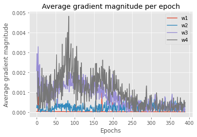

```python
plt.plot(abs(nn4L.grad_w1_[10:]), label='w1')
plt.plot(abs(nn4L.grad_w2_[10:]), label='w2')
plt.plot(abs(nn4L.grad_w3_[10:]), label='w3')
plt.plot(abs(nn4L.grad_w4_[10:]), label='w4')

plt.legend()
plt.title('Average gradient magnitude per epoch')
plt.ylabel('Average gradient magnitude')
plt.xlabel('Epochs')
plt.show()
```

The average gradient magnitude is highest from W4, followed by W3, W2, and W1. An interesting observation is that all magnitudes appear to converge towards 0, unlike the previous graph from the three layer perceptron model. Another detail is that the range for the average gradient magnitudes is much smaller (0.000 - 0.005) compared to that of the three layer perceptron graph (0.0 - 3.0).

From these details, we can assume that the model's performance increased from the 3 layer predecessor, although this may appear contradictory when we look at the four layer perceptron model's 24.99% accuracy in correctly predicting the child poverty rate.

### Fifth Layer Perceptron

We will add a fifth layer to our perceptron model.

```python
from scipy.special import expit
import sys

class FiveLayerPerceptronBase(object):
    def __init__(self, n_hidden=30, n_hidden2 = 15, n_hidden3 = 7, n_hidden4 = 3, C=0.0, epochs=500, eta=0.001, random_state=None):
        np.random.seed(random_state)
        self.n_hidden = n_hidden    # first hidden layer nodes
        self.n_hidden2 = n_hidden2  # second hidden layer nodes
        self.n_hidden3 = n_hidden3  # third hidden layer nodes
        self.n_hidden4 = n_hidden4  # fourth hidden layer nodes

        self.l2_C = C
        self.epochs = epochs
        self.eta = eta

    @staticmethod
    def _encode_labels(y):
        # One-Hot encode labels
        onehot = pd.get_dummies(y).values.T
        return onehot

    def _initialize_weights(self):
        # initialize weights with small random numbers
        W1_num_elems = (self.n_features_)*self.n_hidden
        W1 = np.random.uniform(-1.0, 1.0, size=W1_num_elems)
        W1 = W1.reshape(self.n_hidden, self.n_features_)
        b1 = np.zeros((self.n_hidden, 1))

        W2_num_elems = (self.n_hidden)*self.n_hidden2
        W2 = np.random.uniform(-1.0, 1.0, size=W2_num_elems)
        W2 = W2.reshape(self.n_hidden2, self.n_hidden)
        b2 = np.zeros((self.n_hidden2, 1))

        W3_num_elems = (self.n_hidden2)*self.n_hidden3
        W3 = np.random.uniform(-1.0, 1.0, size=W3_num_elems)
        W3 = W3.reshape(self.n_hidden3, self.n_hidden2)
        b3 = np.zeros((self.n_hidden3, 1))

        W4_num_elems = (self.n_hidden3)*self.n_hidden4
        W4 = np.random.uniform(-1.0, 1.0, size=W4_num_elems)
        W4 = W4.reshape(self.n_hidden4, self.n_hidden3)
        b4 = np.zeros((self.n_hidden4, 1))

        W5_num_elems = (self.n_hidden4)*self.n_output_
        W5 = np.random.uniform(-1.0, 1.0, size=W5_num_elems)
        W5 = W5.reshape(self.n_output_, self.n_hidden4)
        b5 = np.zeros((self.n_output_, 1))

        return W1, W2, W3, W4, W5, b1, b2, b3, b4, b5

    @staticmethod
    def _sigmoid(z):
        # 1.0 / (1.0 + np.exp(-z))
        return expit(z)

    @staticmethod
    def _L2_reg(lambda_, W1, W2, W3, W4, W5):
        # compute L2-regularization cost using W1, W2, W3, W4, W5

        # only compute for non-bias terms
        return (lambda_) * np.sqrt(np.mean(W1 ** 2) + np.mean(W2 ** 2) + np.mean(W3 ** 2) + np.mean(W4 ** 2) + np.mean(W5 ** 2))

    def _cost(self,A6,Y_enc,W1,W2,W3,W4, W5):
        cost = np.mean((Y_enc-A6)**2)
        L2_term = self._L2_reg(self.l2_C, W1, W2, W3, W4, W5)

        return cost + L2_term
```

```python
# adding feedforward and fit and predict functions
class FiveLayerPerceptron(FiveLayerPerceptronBase):
    def _feedforward(self, X, W1, W2, W3, W4, W5, b1, b2, b3, b4, b5):
        """
        X : Input layer with original features.
        W1: Weight matrix for input layer -> hidden layer1.
        W2: Weight matrix for hidden layer1 -> hidden layer2.
        W3: Weight matrix for hidden layer2 -> hidden layer3.
        W4: Weight matrix for hidden layer3 -> hidden layer4.
        W5: Weight matrix for hidden layer4 -> output layer.
        ----------
        a1-a6 : activations into layer (or output layer)
        z1-z5 : layer inputs
        """

        # feedforward into first hidden layer
        A1 = X.T
        Z1 = W1 @ A1 + b1
        A2 = self._sigmoid(Z1)

        # feedforward into second hidden layer
        Z2 = W2 @ A2 + b2
        A3 = self._sigmoid(Z2)

        # feedforward into third hidden layer
        Z3 = W3 @ A3 + b3
        A4 = self._sigmoid(Z3)

        # feedforward into fourth hidden layer
        Z4 = W4 @ A4 + b4
        A5 = self._sigmoid(Z4)

        # feedforward into output layer
        Z5 = W5 @ A5 + b5
        A6 = self._sigmoid(Z5)

        return A1, Z1, A2, Z2, A3, Z3, A4, Z4, A5, Z5, A6

    def _get_gradient(self, A1, A2, A3, A4, A5, A6, Z1, Z2, Z3, Z4, Z5, Y_enc, W1, W2, W3, W4, W5):
        pass


    def predict(self, X):
        _, _, _, _, _, _, _, _, _, _, A6 = self._feedforward(X, self.W1, self.W2, self.W3, self.W4, self.W5, self.b1, self.b2, self.b3, self.b4, self.b5)

        y_pred = np.argmax(A6, axis=0)
        return y_pred


    def fit(self, X, y, print_progress=False):
        # learn weights from training data

        X_data, y_data = X.copy(), y.copy()
        Y_enc = self._encode_labels(y)

        # init weights and setup matrices
        self.n_features_ = X_data.shape[1]
        self.n_output_ = Y_enc.shape[0]
        self.W1, self.W2, self.W3, self.W4, self.W5, self.b1, self.b2, self.b3, self.b4, self.b5 = self._initialize_weights()

        self.cost_ = []

        for i in range(self.epochs):
            if print_progress>0 and (i+1)%print_progress==0:
                sys.stderr.write('\rEpoch: %d/%d' % (i+1, self.epochs))
                sys.stderr.flush()

            # feedforward all instances
            A1, Z1, A2, Z2, A3, Z3, A4, Z4, A5, Z5, A6 = self._feedforward(X_data,self.W1,self.W2,self.W3,self.W4,self.W5,self.b1,self.b2,self.b3,self.b4,self.b5)

            cost = self._cost(A6,Y_enc,self.W1,self.W2,self.W3,self.W4,self.W5)
            self.cost_.append(cost)

            # compute gradient via backpropagation
            gradW1, gradW2, gradW3, gradW4, gradW5, gradb1, gradb2, gradb3, gradb4, gradb5 = self._get_gradient(A1=A1, A2=A2, A3=A3, A4=A4, A5=A5, A6=A6, Z1=Z1, Z2=Z2, Z3=Z3, Z4=Z4, Z5=Z5, Y_enc=Y_enc,
            W1=self.W1, W2=self.W2, W3=self.W3, W4=self.W4, W5=self.W5)

            self.W1 -= self.eta * gradW1
            self.W2 -= self.eta * gradW2
            self.W3 -= self.eta * gradW3
            self.W4 -= self.eta * gradW4
            self.W5 -= self.eta * gradW5

            self.b1 -= self.eta * gradb1
            self.b2 -= self.eta * gradb2
            self.b3 -= self.eta * gradb3
            self.b4 -= self.eta * gradb4
            self.b5 -= self.eta * gradb5

        return self
```

#### Optimization Techniques

```python
class FiveLayerPerceptronVectorized(FiveLayerPerceptron):
    def _get_gradient(self, A1, A2, A3, A4, A5, A6, Z1, Z2, Z3, Z4, Z5, Y_enc, W1, W2, W3, W4, W5):
        # vectorized backpropagation
        V5 = -2*(Y_enc-A6)*A6*(1-A6)
        V4 = A5*(1-A5)*(W5.T @ V5)
        V3 = A4*(1-A4)*(W4.T @ V4)
        V2 = A3*(1-A3)*(W3.T @ V3)
        V1 = A2*(1-A2)*(W2.T @ V2)

        gradW5 = V5 @ A5.T
        gradW4 = V4 @ A4.T
        gradW3 = V3 @ A3.T
        gradW2 = V2 @ A2.T
        gradW1 = V1 @ A1.T

        gradb5 = np.sum(V5, axis=1).reshape((-1,1))
        gradb4 = np.sum(V4, axis=1).reshape((-1,1))
        gradb3 = np.sum(V3, axis=1).reshape((-1,1))
        gradb2 = np.sum(V2, axis=1).reshape((-1,1))
        gradb1 = np.sum(V1, axis=1).reshape((-1,1))

        # regularize weights that are not bias terms
        gradW1 += W1 * self.l2_C
        gradW2 += W2 * self.l2_C
        gradW3 += W3 * self.l2_C
        gradW4 += W4 * self.l2_C
        gradW5 += W5 * self.l2_C

        return gradW1, gradW2, gradW3, gradW4, gradW5, gradb1, gradb2, gradb3, gradb4, gradb5
```

```python
# adding mini-batching to Two Layer Perceptron class
class FiveLPMiniBatch(FiveLayerPerceptronVectorized):
    def __init__(self, alpha=0.0, decrease_const=0.1, decrease_iter = 10, shuffle=True, minibatches=1, **kwds):
        # need to add to the original initializer
        self.alpha = alpha
        self.decrease_const = decrease_const
        self.decrease_iter = decrease_iter
        self.shuffle = shuffle
        self.minibatches = minibatches

        # but keep other keywords
        super().__init__(**kwds)


    def fit(self, X, y, print_progress=False, XY_test=None):
        # learn weights from training data with mini-batch
        X_data, y_data = X.copy(), y.copy()
        Y_enc = self._encode_labels(y)

        # init weights and setup matrices
        self.n_features_ = X_data.shape[1]
        self.n_output_ = Y_enc.shape[0]
        self.W1, self.W2, self.W3, self.W4, self.W5, self.b1, self.b2, self.b3, self.b4, self.b5 = self._initialize_weights()

        # start momentum at zero for previous updates
        rho_W1_prev = np.zeros(self.W1.shape) # for momentum
        rho_W2_prev = np.zeros(self.W2.shape) # for momentum
        rho_W3_prev = np.zeros(self.W3.shape) # for momentum
        rho_W4_prev = np.zeros(self.W4.shape) # for momentum
        rho_W5_prev = np.zeros(self.W5.shape) # for momentum

        # create arrays for average magnitude of weights
        self.grad_w1_ = np.zeros(self.epochs)
        self.grad_w2_ = np.zeros(self.epochs)
        self.grad_w3_ = np.zeros(self.epochs)
        self.grad_w4_ = np.zeros(self.epochs)
        self.grad_w5_ = np.zeros(self.epochs)

        self.cost_ = []
        self.score_ = []

        # get starting acc
        self.score_.append(accuracy_score(y_data,self.predict(X_data)))

        # keep track of validation, if given
        if XY_test is not None:
            X_test = XY_test[0].copy()
            y_test = XY_test[1].copy()

            self.val_score_ = []
            self.val_score_.append(accuracy_score(y_test,self.predict(X_test)))
            self.val_cost_ = []

        for i in range(self.epochs):
            eta = self.eta

            if print_progress>0 and (i+1)%print_progress==0:
                sys.stderr.write('\rEpoch: %d/%d' % (i+1, self.epochs))
                sys.stderr.flush()

            if self.shuffle:
                idx_shuffle = np.random.permutation(y_data.shape[0])
                X_data, Y_enc, y_data = X_data[idx_shuffle], Y_enc[:, idx_shuffle], y_data[idx_shuffle]

            mini = np.array_split(range(y_data.shape[0]), self.minibatches)
            mini_cost = []

            self.grad_w1_batch = []
            self.grad_w2_batch = []
            self.grad_w3_batch = []
            self.grad_w4_batch = []
            self.grad_w5_batch = []

            for idx in mini:

                # feedforward
                A1, Z1, A2, Z2, A3, Z3, A4, Z4, A5, Z5, A6 = self._feedforward(X_data[idx],
                                                       self.W1,
                                                       self.W2,
                                                       self.W3,
                                                       self.W4,
                                                       self.W5,
                                                       self.b1,
                                                       self.b2,
                                                       self.b3,
                                                       self.b4,
                                                       self.b5
                                                      )

                cost = self._cost(A6,Y_enc[:, idx],self.W1,self.W2,self.W3,self.W4,self.W5)
                mini_cost.append(cost) # this appends cost of mini-batch only

                # compute gradient via backpropagation
                gradW1, gradW2, gradW3, gradW4, gradW5, gradb1, gradb2, gradb3, gradb4, gradb5= self._get_gradient(A1=A1, A2=A2, A3=A3, A4=A4, A5=A5, A6=A6, Z1=Z1, Z2=Z2, Z3=Z3, Z4=Z4, Z5=Z5,
                                                  Y_enc=Y_enc[:, idx],
                                                  W1=self.W1,W2=self.W2,W3=self.W3,W4=self.W4,W5=self.W5)

                self.grad_w1_batch.append(np.mean(gradW1))
                self.grad_w2_batch.append(np.mean(gradW2))
                self.grad_w3_batch.append(np.mean(gradW3))
                self.grad_w4_batch.append(np.mean(gradW4))
                self.grad_w5_batch.append(np.mean(gradW5))

                # momentum calculations
                rho_W1, rho_W2, rho_W3, rho_W4, rho_W5 = eta * gradW1, eta * gradW2, eta * gradW3, eta * gradW4, eta * gradW5

                self.W1 -= (rho_W1 + (self.alpha * rho_W1_prev)) # update with momentum
                self.W2 -= (rho_W2 + (self.alpha * rho_W2_prev)) # update with momentum
                self.W3 -= (rho_W3 + (self.alpha * rho_W3_prev)) # update with momentum
                self.W4 -= (rho_W4 + (self.alpha * rho_W4_prev)) # update with momentum
                self.W5 -= (rho_W5 + (self.alpha * rho_W5_prev)) # update with momentum

                self.b1 -= eta * gradb1
                self.b2 -= eta * gradb2
                self.b3 -= eta * gradb3
                self.b4 -= eta * gradb4
                self.b5 -= eta * gradb5

                rho_W1_prev, rho_W2_prev, rho_W3_prev, rho_W4_prev, rho_W5_prev = rho_W1, rho_W2, rho_W3, rho_W4, rho_W5

            self.grad_w1_batch = np.array(self.grad_w1_batch)
            self.grad_w2_batch = np.array(self.grad_w2_batch)
            self.grad_w3_batch = np.array(self.grad_w3_batch)
            self.grad_w4_batch = np.array(self.grad_w4_batch)
            self.grad_w5_batch = np.array(self.grad_w5_batch)


            self.grad_w1_[i] = np.mean(self.grad_w1_batch)
            self.grad_w2_[i] = np.mean(self.grad_w2_batch)
            self.grad_w3_[i] = np.mean(self.grad_w3_batch)
            self.grad_w4_[i] = np.mean(self.grad_w4_batch)
            self.grad_w5_[i] = np.mean(self.grad_w5_batch)

            self.cost_.append(np.mean(mini_cost))
            self.score_.append(accuracy_score(y_data,self.predict(X_data)))
            if XY_test is not None:
                yhat = self.predict(X_test)
                self.val_score_.append(accuracy_score(y_test,yhat))

        return self
```

```python
# add cross entropy to TLPMiniBatch class
class FiveLPMiniBatchCrossEntropy(FiveLPMiniBatch):
    def _cost(self,A6,Y_enc,W1,W2,W3,W4,W5):
        cost = -np.mean(np.nan_to_num((Y_enc*np.log(A6)+(1-Y_enc)*np.log(1-A6))))
        L2_term = self._L2_reg(self.l2_C, W1,W2,W3,W4,W5)

        return cost + L2_term

    def _get_gradient(self, A1, A2, A3, A4, A5, A6,Z1, Z2, Z3, Z4, Z5, Y_enc, W1, W2, W3, W4, W5):
        # compute gradient step using backpropagation

        # vectorized backpropagation
        V5 = (A6-Y_enc) # <- this is only line that changed
        V4 = A5*(1-A5)*(W5.T @ V5)
        V3 = A4*(1-A4)*(W4.T @ V4)
        V2 = A3*(1-A3)*(W3.T @ V3)
        V1 = A2*(1-A2)*(W2.T @ V2)

        gradW5 = V5 @ A5.T
        gradW4 = V4 @ A4.T
        gradW3 = V3 @ A3.T
        gradW2 = V2 @ A2.T
        gradW1 = V1 @ A1.T

        gradb5 = np.sum(V5, axis=1).reshape((-1,1))
        gradb4 = np.sum(V4, axis=1).reshape((-1,1))
        gradb3 = np.sum(V3, axis=1).reshape((-1,1))
        gradb2 = np.sum(V2, axis=1).reshape((-1,1))
        gradb1 = np.sum(V1, axis=1).reshape((-1,1))

        # regularize weights that are not bias terms
        gradW1 += W1 * self.l2_C
        gradW2 += W2 * self.l2_C
        gradW3 += W3 * self.l2_C
        gradW4 += W4 * self.l2_C
        gradW5 += W5 * self.l2_C

        return gradW1, gradW2, gradW3, gradW4, gradW5, gradb1, gradb2, gradb3, gradb4, gradb5
```

```python
# derive class with Glorot Initialization
class FiveLPBetterInitial(FiveLPMiniBatchCrossEntropy):
    def _initialize_weights(self):
        # initialize weights Glorot and He normalization
        init_bound = 4*np.sqrt(6. / (self.n_hidden + self.n_features_))
        W1 = np.random.uniform(-init_bound, init_bound,(self.n_hidden, self.n_features_))

        # reduce the final layer magnitude in order to balance the size of the gradients
        init_bound = 4*np.sqrt(6 / (self.n_hidden2 + self.n_hidden))
        W2 = np.random.uniform(-init_bound, init_bound,(self.n_hidden2, self.n_hidden))

        init_bound = 4*np.sqrt(6 / (self.n_hidden3+ self.n_hidden2))
        W3 = np.random.uniform(-init_bound, init_bound,(self.n_hidden3, self.n_hidden2))

        init_bound = 4*np.sqrt(6 / (self.n_hidden4 + self.n_hidden3))
        W4 = np.random.uniform(-init_bound, init_bound,(self.n_hidden4, self.n_hidden3))

        init_bound = 4*np.sqrt(6 / (self.n_output_ + self.n_hidden4))
        W5 = np.random.uniform(-init_bound, init_bound,(self.n_output_, self.n_hidden4))

        b1 = np.zeros((self.n_hidden, 1))
        b2 = np.zeros((self.n_hidden2, 1))
        b3 = np.zeros((self.n_hidden3, 1))
        b4 = np.zeros((self.n_hidden4, 1))
        b5 = np.zeros((self.n_output_, 1))

        return W1, W2, W3, W4, W5, b1, b2, b3, b4, b5
```

#### Testing Perceptron

```python
l5vals = {
    'n_hidden':50,
    'n_hidden2':40,
    'n_hidden3':30,
    'n_hidden4':20,
    'C':1e-2,
    'epochs':400,
    'eta':0.001,
    'alpha':0.1,
    'decrease_const':0.1,
    'decrease_iter':20,
    'minibatches':int(len(X_train))/256,
    'shuffle':True,
    'random_state':1
}
```

```python
nn5L = FiveLPBetterInitial(**l5vals)
nn5L.fit(X_train.to_numpy(), y_train.to_numpy(), print_progress=1)

yhat = nn5L.predict(X_test.to_numpy())
acc5L = accuracy_score(y_test.to_numpy(),yhat)
print('Accuracy:',acc5L)
```

```
Epoch: 400/400
```

```
Accuracy: 0.24986248624862487
```

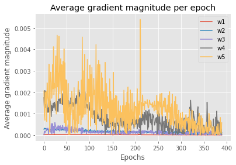

```python
plt.plot(abs(nn5L.grad_w1_[10:]), label='w1')
plt.plot(abs(nn5L.grad_w2_[10:]), label='w2')
plt.plot(abs(nn5L.grad_w3_[10:]), label='w3')
plt.plot(abs(nn5L.grad_w4_[10:]), label='w4')
plt.plot(abs(nn5L.grad_w5_[10:]), label='w5')

plt.legend()
plt.title('Average gradient magnitude per epoch')
plt.ylabel('Average gradient magnitude')
plt.xlabel('Epochs')
plt.show()
```

As we have observed from the previous perceptron models, the highest average gradient magnitude comes from the hidden layer closest the the output layer. In this case, it happens to be W5, followed by W4, W3, W2, and W1. It should be noted that the average gradient magnitude remained the same from the five layer perceptron (0.000 - 0.005) to the four layer perceptron (0.000 - 0.005). The accuracy of this perceptron model did not improve. In fact, it decreased by a very slight margin.

### Adaptive Learning Techniques

We will be implementing two separate adaptive learning techniques to compare to the performance of our five layer perceptron model. Below is the perceptron model that can change between no adaptive learning technique, RMSProps, and AdaGrad. We will provide an analysis of the performances at the end of this section as we compare their graphs side-by-side.

```python
"""Deriving the class with mini-batching added in conjuction with AdaM"""
class FiveLPMiniBatch_withMultiAdaptive(FiveLPBetterInitial):
    def __init__(self, beta=0.9, optimizer='default',**kwds):
        # add new parameters
        self.beta = beta
        self.optimizer = optimizer

        # keep other keywords
        super().__init__(**kwds)


    def fit(self, X, y, print_progress=False):
        X_data, y_data = X.copy(), y.copy()
        Y_enc = self._encode_labels(y)

        # init weights and setup matrices
        self.n_features_ = X_data.shape[1]
        self.n_output_ = Y_enc.shape[0]
        self.W1, self.W2, self.W3, self.W4, self.W5, self.b1, self.b2, self.b3, self.b4, self.b5 = self._initialize_weights()

        self.cost_ = []

        self.grad_1_ = []
        self.grad_2_ = []
        self.grad_3_ = []
        self.grad_4_ = []
        self.grad_5_ = []

        self.gradb1 = []
        self.gradb2 = []
        self.gradb3 = []
        self.gradb4 = []
        self.gradb5 = []

        self.G1 = self.G2 = self.G3 = self.G4 = self.G5 = 0
        self.epsilon = 1e-10

        for i in range(self.epochs):
            eta = self.eta

            if print_progress>0 and (i+1)%print_progress==0:
                sys.stderr.write('\rEpoch: %d/%d' % (i+1, self.epochs))
                sys.stderr.flush()

            # feedforward all instances
            A1, Z1, A2, Z2, A3, Z3, A4, Z4, A5, Z5, A6 = self._feedforward(X_data,
                                                       self.W1,
                                                       self.W2,
                                                       self.W3,
                                                       self.W4,
                                                       self.W5,
                                                       self.b1,
                                                       self.b2,
                                                       self.b3,
                                                       self.b4,
                                                       self.b5
                                                      )


            cost = self._cost(A6,Y_enc,self.W1,self.W2,self.W3,self.W4,self.W5)
            self.cost_.append(cost)

            # compute gradient via backpropagation
            gradW1, gradW2, gradW3, gradW4, gradW5, gradb1, gradb2, gradb3, gradb4, gradb5 = self._get_gradient(A1=A1, A2=A2, A3=A3, A4=A4, A5=A5, A6=A6, Z1=Z1, Z2=Z2, Z3=Z3, Z4=Z4, Z5=Z5,
                                                  Y_enc=Y_enc,
                                                  W1=self.W1,W2=self.W2,W3=self.W3,W4=self.W4,W5=self.W5)

            if self.optimizer == 'default':
                self.W1 -= self.eta * gradW1
                self.W2 -= self.eta * gradW2
                self.W3 -= self.eta * gradW3
                self.W4 -= self.eta * gradW4
                self.W5 -= self.eta * gradW5

                self.b1 -= eta * gradb1
                self.b2 -= eta * gradb2
                self.b3 -= eta * gradb3
                self.b4 -= eta * gradb4
                self.b5 -= eta * gradb5

            elif self.optimizer == 'RMSProp':
                self.G1 = self.beta * self.G1 + (1-self.beta)*(gradW1**2)
                self.G2 = self.beta * self.G2 + (1-self.beta)*(gradW2**2)
                self.G3 = self.beta * self.G3 + (1-self.beta)*(gradW3**2)
                self.G4 = self.beta * self.G4 + (1-self.beta)*(gradW4**2)
                self.G5 = self.beta * self.G5 + (1-self.beta)*(gradW5**2)

                self.W1 -= self.eta * gradW1 / (np.sqrt(self.G1)+self.epsilon)
                self.W2 -= self.eta * gradW2 / (np.sqrt(self.G2)+self.epsilon)
                self.W3 -= self.eta * gradW3 / (np.sqrt(self.G3)+self.epsilon)
                self.W4 -= self.eta * gradW4 / (np.sqrt(self.G4)+self.epsilon)
                self.W5 -= self.eta * gradW5 / (np.sqrt(self.G5)+self.epsilon)

                self.b1 -= eta * gradb1
                self.b2 -= eta * gradb2
                self.b3 -= eta * gradb3
                self.b4 -= eta * gradb4
                self.b5 -= eta * gradb5


            elif self.optimizer == 'Adagrad':
                self.G1 += np.square(gradW1)
                self.G2 += np.square(gradW2)
                self.G3 += np.square(gradW3)
                self.G4 += np.square(gradW4)
                self.G5 += np.square(gradW5)

                self.W1 -= self.eta * gradW1 / (np.sqrt(self.G1)+self.epsilon)
                self.W2 -= self.eta * gradW2 / (np.sqrt(self.G2)+self.epsilon)
                self.W3 -= self.eta * gradW3 / (np.sqrt(self.G3)+self.epsilon)
                self.W4 -= self.eta * gradW4 / (np.sqrt(self.G4)+self.epsilon)
                self.W5 -= self.eta * gradW5 / (np.sqrt(self.G5)+self.epsilon)

                self.b1 -= eta * gradb1
                self.b2 -= eta * gradb2
                self.b3 -= eta * gradb3
                self.b4 -= eta * gradb4
                self.b5 -= eta * gradb5

            self.grad_1_.append(np.mean(gradW1))
            self.grad_2_.append(np.mean(gradW2))
            self.grad_3_.append(np.mean(gradW3))
            self.grad_4_.append(np.mean(gradW4))
            self.grad_5_.append(np.mean(gradW5))

        return self
```

#### RMSProps

```python
rmsvals = {
    'n_hidden':50,
    'n_hidden2':40,
    'n_hidden3':30,
    'n_hidden4':20,
    'C':1e-2,
    'epochs':400,
    'eta':0.001,
    'alpha':0.1,
    'decrease_const':0.1,
    'decrease_iter':20,
    'beta':0.9,
    'optimizer':'RMSProp',
    'minibatches':int(len(X_train))/256,
    'shuffle':True,
    'random_state':1
}
```

```
Epoch: 400/400
```

```
Accuracy: 0.2495874587458746
```

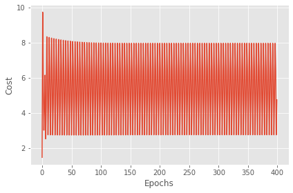

```python
nn_5_RMSProp = FiveLPMiniBatch_withMultiAdaptive(**rmsvals)

nn_5_RMSProp.fit(X_train.to_numpy(), y_train.to_numpy(), print_progress=1)
yhat_RMSProp = nn_5_RMSProp.predict(X_test.to_numpy())
print('Accuracy:',accuracy_score(y_test,yhat_RMSProp))

plt.plot(range(len(nn_5_RMSProp.cost_)), nn_5_RMSProp.cost_)
plt.ylabel('Cost')
plt.xlabel('Epochs')
plt.tight_layout()
plt.show()
```

#### AdaGrad

```python
adagrvals = {
    'n_hidden':50,
    'n_hidden2':40,
    'n_hidden3':30,
    'n_hidden4':20,
    'C':1e-2,
    'epochs':400,
    'eta':0.001,
    'alpha':0.1,
    'decrease_const':0.1,
    'decrease_iter':20,
    'beta':0.9,
    'optimizer':'Adagrad',
    'minibatches':int(len(X_train))/256,
    'shuffle':True,
    'random_state':1
}
```

```
Epoch: 400/400
```

```
Accuracy: 0.2495874587458746
```

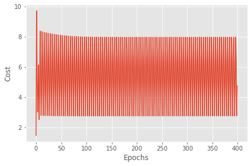

```python
nn_5_Adagrad = FiveLPMiniBatch_withMultiAdaptive(**adagrvals)

nn_5_Adagrad.fit(X_train.to_numpy(), y_train.to_numpy(), print_progress=1)
yhat_Adagrad = nn_5_Adagrad.predict(X_test.to_numpy())
print('Accuracy:',accuracy_score(y_test,yhat_Adagrad))

plt.plot(range(len(nn_5_Adagrad.cost_)), nn_5_Adagrad.cost_)
plt.ylabel('Cost')
plt.xlabel('Epochs')
plt.tight_layout()
plt.show()
```

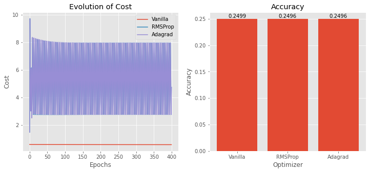

```python
plt.figure(figsize=(12,5))

ax1 = plt.subplot(121)
plt.plot(range(len(nn5L.cost_)), nn5L.cost_)
plt.plot(range(len(nn_5_RMSProp.cost_)), nn_5_RMSProp.cost_)
plt.plot(range(len(nn_5_Adagrad.cost_)), nn_5_Adagrad.cost_)

plt.xlabel('Epochs')
plt.ylabel('Cost')
plt.title('Evolution of Cost')
plt.legend(['Vanilla','RMSProp','Adagrad'])

ax2 = plt.subplot(122)
yhat = nn5L.predict(X_test.to_numpy())
accuracy = accuracy_score(y_test.to_numpy(),yhat)

yhat_RMSProp = nn_5_RMSProp.predict(X_test.to_numpy())
accuracy_RMSProp = accuracy_score(y_test.to_numpy(),yhat_RMSProp)

yhat_Adagrad = nn_5_Adagrad.predict(X_test.to_numpy())
accuracy_Adagrad = accuracy_score(y_test.to_numpy(),yhat_Adagrad)
x = [1,2,3]
y = [accuracy,accuracy_RMSProp,accuracy_Adagrad]
plt.bar(x,y)
plt.xlabel('Optimizer')
plt.ylabel('Accuracy')
plt.title('Accuracy')
ax2.set_xticks(x)
ax2.set_xticklabels(['Vanilla','RMSProp','Adagrad'])

for x, y in zip(x, y):
    plt.text(x, y, '%.4f'%y, ha='center', va='bottom')

plt.show()
```

It is interesting to note how the cost oscillates between 8 and 3 for both the RMSProps and AdaGrad models, never seeming to converge towards 0 or another single value. Despite using these technique, both models' accuracy is lower than the normal five layer perceptron model. Thus, we conclude that the use of these adaptive learning techniques did not improve our perceptron model's performance.

## Gradate Analysis: AdaM

We will be adding a five layer perceptron model that uses the AdaM technique and compare its results to the previous five layer perceptron models. Again, we will compare them side-by-side at the end of this section.

```python
class FiveLayerPerceptronAdaM(FiveLPBetterInitial):
    def __init__(self, beta_1=0.9, beta_2=0.99,**kwds):
        # nadd new parameters
        self.beta_1 = beta_1
        self.beta_2 = beta_2


        # keep other keywords
        super().__init__(**kwds)

    def fit(self, X, y, print_progress=False):
        """ Learn weights from training data."""

        X_data, y_data = X.copy(), y.copy()
        Y_enc = self._encode_labels(y)

        # init weights and setup matrices
        self.n_features_ = X_data.shape[1]
        self.n_output_ = Y_enc.shape[0]
        self.W1, self.W2, self.W3, self.W4, self.W5, self.b1, self.b2, self.b3, self.b4, self.b5 = self._initialize_weights()

        self.cost_ = []
        self.grad_1_ = []
        self.grad_2_ = []
        self.grad_3_ = []
        self.grad_4_ = []
        self.grad_5_ = []

        self.gradb1 = []
        self.gradb2 = []
        self.gradb3 = []
        self.gradb4 = []
        self.gradb5 = []

        self.m1 = self.m2 = self.m3 = self.m4 = self.m5 = 0
        self.v1 = self.v2 = self.v3 = self.v4 = self.v5 = 0
        self.m_hat1 = self.m_hat2 = self.m_hat3 = self.m_hat4 = self.m_hat5 = 0;
        self.v_hat1 = self.v_hat2 = self.v_hat3 = self.v_hat4 = self.v_hat5 = 0;

        self.epsilon = 1e-10
        for t in range(self.epochs):

            eta = self.eta

            if print_progress>0 and (t+1)%print_progress==0:
                sys.stderr.write('\rEpoch: %d/%d' % (t+1, self.epochs))
                sys.stderr.flush()

            # feedforward all instances
            A1, Z1, A2, Z2, A3, Z3, A4, Z4, A5, Z5, A6 = self._feedforward(X_data,
                                                       self.W1,
                                                       self.W2,
                                                       self.W3,
                                                       self.W4,
                                                       self.W5,
                                                       self.b1,
                                                       self.b2,
                                                       self.b3,
                                                       self.b4,
                                                       self.b5
                                                      )


            cost = self._cost(A6,Y_enc,self.W1,self.W2,self.W3,self.W4,self.W5)
            self.cost_.append(cost)

            # compute gradient via backpropagation
            gradW1, gradW2, gradW3, gradW4, gradW5, gradb1, gradb2, gradb3, gradb4, gradb5 = self._get_gradient(A1=A1, A2=A2, A3=A3, A4=A4, A5=A5, A6=A6, Z1=Z1, Z2=Z2, Z3=Z3, Z4=Z4, Z5=Z5,
                                                  Y_enc=Y_enc,
                                                  W1=self.W1,W2=self.W2,W3=self.W3,W4=self.W4,W5=self.W5)



            self.m1 = self.beta_1 * self.m1 + (1 - self.beta_1) * gradW1
            self.m2 = self.beta_1 * self.m2 + (1 - self.beta_1) * gradW2
            self.m3 = self.beta_1 * self.m3 + (1 - self.beta_1) * gradW3
            self.m4 = self.beta_1 * self.m4 + (1 - self.beta_1) * gradW4
            self.m5 = self.beta_1 * self.m5 + (1 - self.beta_1) * gradW5

            self.v1 = self.beta_2 * self.v1 + (1 - self.beta_2) * np.power(gradW1, 2)
            self.v2 = self.beta_2 * self.v2 + (1 - self.beta_2) * np.power(gradW2, 2)
            self.v3 = self.beta_2 * self.v3 + (1 - self.beta_2) * np.power(gradW3, 2)
            self.v4 = self.beta_2 * self.v4 + (1 - self.beta_2) * np.power(gradW4, 2)
            self.v5 = self.beta_2 * self.v5 + (1 - self.beta_2) * np.power(gradW5, 2)

            self.m_hat1 = self.m1 / (1 - np.power(self.beta_1, t+1))
            self.m_hat2 = self.m2 / (1 - np.power(self.beta_1, t+1))
            self.m_hat3 = self.m3 / (1 - np.power(self.beta_1, t+1))
            self.m_hat4 = self.m4 / (1 - np.power(self.beta_1, t+1))
            self.m_hat5 = self.m5 / (1 - np.power(self.beta_1, t+1))

            self.v_hat1 = self.v1 / (1 - np.power(self.beta_2, t+1))
            self.v_hat2 = self.v2 / (1 - np.power(self.beta_2, t+1))
            self.v_hat3 = self.v3 / (1 - np.power(self.beta_2, t+1))
            self.v_hat4 = self.v4 / (1 - np.power(self.beta_2, t+1))
            self.v_hat5 = self.v5 / (1 - np.power(self.beta_2, t+1))


            self.W1 = self.W1 - self.eta * self.m_hat1 / (np.sqrt(self.v_hat1) + self.epsilon)
            self.W2 = self.W2 - self.eta * self.m_hat2 / (np.sqrt(self.v_hat2) + self.epsilon)
            self.W3 = self.W3 - self.eta * self.m_hat3 / (np.sqrt(self.v_hat3) + self.epsilon)
            self.W4 = self.W4 - self.eta * self.m_hat4 / (np.sqrt(self.v_hat4) + self.epsilon)
            self.W5 = self.W5 - self.eta * self.m_hat5 / (np.sqrt(self.v_hat5) + self.epsilon)

            self.b1 -= eta * gradb1
            self.b2 -= eta * gradb2
            self.b3 -= eta * gradb3
            self.b4 -= eta * gradb4
            self.b5 -= eta * gradb5


            self.grad_1_.append(np.mean(gradW1))
            self.grad_2_.append(np.mean(gradW2))
            self.grad_3_.append(np.mean(gradW3))
            self.grad_4_.append(np.mean(gradW4))
            self.grad_5_.append(np.mean(gradW5))

        return self
```

```python
class AdamTLPVectorizedMiniBatch(FiveLayerPerceptronVectorized):
    def __init__(self, alpha=0.1, decrease_const=0.0, beta_1=.9, beta_2=.999, shuffle=True, minibatches=1, **kwds):
        # need to add to the original initializer
        self.alpha = alpha
        self.decrease_const = decrease_const
        self.shuffle = shuffle
        self.minibatches = minibatches
        # but keep other keywords
        super().__init__(**kwds)

    def fit(self, X, y, print_progress=0):
        """ Learn weights from training data."""
        X_data, y_data = X.copy(), y.copy()
        Y_enc = self._encode_labels(y)

        # init weights and setup matrices
        self.n_features_ = X_data.shape[1]
        self.n_output_ = Y_enc.shape[0]
        self.W1, self.W2, self.W3, self.W4, self.W5 = self._initialize_weights()

        # start momentum at zero for previous updates
        rho_W1_prev = np.zeros(self.W1.shape) # for momentum
        rho_W2_prev = np.zeros(self.W2.shape) # for momentum
        rho_W3_prev = np.zeros(self.W3.shape)
        rho_W4_prev = np.zeros(self.W4.shape)
        rho_W5_prev = np.zeros(self.W5.shape)

        self.cost_ = []
        for k in range(self.epochs):

            # adaptive learning rate
            M=beta_1*self.M+(1-beta_1)*self._get_gradient
            V=beta_2*self.V+(1-beta_2)*(self._get_gradient)^2
            M_hat=self.M/(1-beta_1^k)
            V_hat=self.V/(1-beta_2^k)
            eta = self.eta**(1+self.decrease_const*k)# decreasing learning rate
            eta = max(eta,self.eta/1000)
            W=self.W-eta*M_hat/(np.sqrt(V_hat+.00001))
            # there are many forms of adaptive learning rates out there!

            if print_progress>0 and (k+1)%print_progress==0:
                sys.stderr.write('\rEpoch: %d/%d' % (k+1, self.epochs))
                sys.stderr.flush()

            if self.shuffle:
                ridx = np.random.permutation(y_data.shape[0])
                X_data, Y_enc = X_data[ridx], Y_enc[:, ridx]

            # use numpy split to split into equal sized batches
            # num batches== self.minibatches
            mini = np.array_split(range(y_data.shape[0]), self.minibatches)
            mini_cost = []
            for idx in mini:

                # feedforward
                A1, Z1, A2, Z2, A3, Z3, A4, Z4, A5, Z5, A6 = self._feedforward(X_data[idx],
                                                       self.W1,
                                                       self.W2,
                                                       self.W3,
                                                       self.W4,
                                                       self.W5)

                cost = self._cost(A6,Y_enc[:, idx],self.W1,self.W2,self.W3,self.W4,self.W5)
                mini_cost.append(cost) # this appends cost of mini-batch only

                # compute gradient via backpropagation
                grad1, grad2, grad3, grad4, grad5 = self._get_gradient(A1=A1, A2=A2, A3=A3, A4=A4, A5=A5, A6=A6, Z1=Z1, Z2=Z2, Z3=Z3, Z4=Z4, Z5=Z5,
                                                  Y_enc=Y_enc[:, idx],
                                                  W1=self.W1, W2=self.W2, W3=self.W3, W4=self.W4, W5=self.W5)

                rho_W1, rho_W2, rho_W3, rho_W4, rho_W5 = eta * grad1, eta * grad2, eta * grad3, eta * grad4, eta * grad5
                self.W1 -= (rho_W1 + (self.alpha * rho_W1_prev))
                self.W2 -= (rho_W2 + (self.alpha * rho_W2_prev))
                self.W3 -= (rho_W3 + (self.alpha * rho_W3_prev))
                self.W4 -= (rho_W4 + (self.alpha * rho_W4_prev))
                self.W5 -= (rho_W5 + (self.alpha * rho_W5_prev))
                rho_W1_prev, rho_W2_prev, rho_W3_prev, rho_W4_prev, rho_W5_prev = rho_W1, rho_W2, rho_W3, rho_W4, rho_W5

            self.cost_.append(mini_cost)

        return self
```

```python
valsAda = {
    'n_hidden':50,
    'n_hidden2':40,
    'n_hidden3':30,
    'n_hidden4':20,
    'C':1e-2,
    'epochs':400,
    'eta':0.001,
    'alpha':0.1,
    'decrease_const':0.1,
    'decrease_iter':20,
    'beta_1':0.9,
    'beta_2':0.99,
    'minibatches':int(len(X_train))/256,
    'shuffle':True,
    'random_state':1
}
```

```python
nn_5_AdaM = FiveLayerPerceptronAdaM(**valsAda)
nn_5_AdaM.fit(X_train.to_numpy(), y_train.to_numpy(), print_progress=10)
yhat_AdaM = nn_5_AdaM.predict(X_test.to_numpy())
print('Accuracy:',accuracy_score(y_test.to_numpy(),yhat_AdaM))
```

```
Epoch: 400/400
```

```
Accuracy: 0.2495874587458746
```

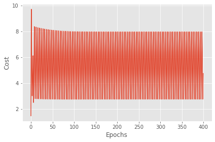

```python
plt.plot(range(len(nn_5_AdaM.cost_)), nn_5_AdaM.cost_)
plt.ylabel('Cost')
plt.xlabel('Epochs')
plt.tight_layout()
plt.show()
```

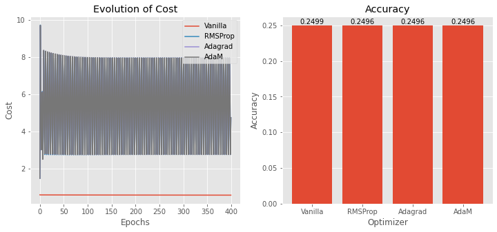

```python
plt.figure(figsize=(12,5))

ax1 = plt.subplot(121)
plt.plot(range(len(nn5L.cost_)), nn5L.cost_)
plt.plot(range(len(nn_5_RMSProp.cost_)), nn_5_RMSProp.cost_)
plt.plot(range(len(nn_5_Adagrad.cost_)), nn_5_Adagrad.cost_)
plt.plot(range(len(nn_5_AdaM.cost_)), nn_5_AdaM.cost_)

plt.xlabel('Epochs')
plt.ylabel('Cost')
plt.title('Evolution of Cost')
plt.legend(['Vanilla','RMSProp','Adagrad','AdaM'])


ax2 = plt.subplot(122)
yhat = nn5L.predict(X_test.to_numpy())
accuracy = accuracy_score(y_test.to_numpy(),yhat)

yhat_RMSProp = nn_5_RMSProp.predict(X_test.to_numpy())
accuracy_RMSProp = accuracy_score(y_test.to_numpy(),yhat_RMSProp)

yhat_Adagrad = nn_5_Adagrad.predict(X_test.to_numpy())
accuracy_Adagrad = accuracy_score(y_test,yhat_Adagrad)

yhat_AdaM = nn_5_AdaM.predict(X_test.to_numpy())
accuracy_AdaM = accuracy_score(y_test,yhat_AdaM)

x = [1,2,3,4]
y = [accuracy,accuracy_RMSProp,accuracy_Adagrad, accuracy_AdaM]
plt.bar(x,y)
plt.xlabel('Optimizer')
plt.ylabel('Accuracy')
plt.title('Accuracy')
ax2.set_xticks(x)
ax2.set_xticklabels(['Vanilla','RMSProp','Adagrad','AdaM'])

for x, y in zip(x, y):
    plt.text(x, y, '%.4f'%y, ha='center', va='bottom')

plt.show()
```

The models that use an adaptive learning technique have the exact same graphs when visualizing cost. Regarding the normal five layer model, its cost remains extremely low and constant.

The model with the best accuracy is the normal five layer perceptron model (24.99%), followed by the other models with the exact same accuracy (24.96%). The difference is almost insignificant (0.03%), and without these graphs, these models could be generalized as having the same poor performance.

Code used in this notebook was adapted from Professor Larson's notebooks for this class.  
We appreciate Professor Larson's models.